# CausalMachineLearning_Without GWAS_FinalReport

## In the JupyterLab Terminal

Run the following commands: echo $WORKSPACE_BUCKET

This is my workspace bucket: gs://fc-secure-9efd2d24-ec88-48f9-b31c-6d0687da19d7

Copy the entire ici_aki_project/ folder from the data manager's bucket to my workspace bucket: gsutil -m cp -r gs://fc-secure-ee2d193a-0b1e-4010-abf9-05aaef62c2e0/ici_aki_project/ gs://fc-secure-9efd2d24-ec88-48f9-b31c-6d0687da19d7/ici_aki_project/

## In the Jupyter Notebook

```python
# import necessary packages

from datetime import date
import numpy as np
import pandas as pd
import matplotlib as mpl
import seaborn as sns
import matplotlib.pyplot as plt
from datetime import datetime
import dateutil
from IPython.display import display, HTML
import os
import subprocess
```

```python
# This snippet assumes that you run setup first and This code lists datasets in project folder

# Get the bucket name
my_bucket = os.getenv('WORKSPACE_BUCKET')

# List objects in the bucket
print(subprocess.check_output(f"gsutil ls -r {my_bucket}/ici_aki_project/", shell=True).decode('utf-8'))
```

```
gs://fc-secure-9efd2d24-ec88-48f9-b31c-6d0687da19d7/ici_aki_project/:

gs://fc-secure-9efd2d24-ec88-48f9-b31c-6d0687da19d7/ici_aki_project/data/:
gs://fc-secure-9efd2d24-ec88-48f9-b31c-6d0687da19d7/ici_aki_project/data/AKI_ICI_como_YC_06292025.csv
gs://fc-secure-9efd2d24-ec88-48f9-b31c-6d0687da19d7/ici_aki_project/data/AKI_ICI_cox_phenotype_YW_02152024.csv
gs://fc-secure-9efd2d24-ec88-48f9-b31c-6d0687da19d7/ici_aki_project/data/AKI_ICI_ici_genotype15_YW_02202024.csv
gs://fc-secure-9efd2d24-ec88-48f9-b31c-6d0687da19d7/ici_aki_project/data/AKI_ICI_insu_YC_06292025.csv
gs://fc-secure-9efd2d24-ec88-48f9-b31c-6d0687da19d7/ici_aki_project/data/AKI_ICI_sdoh_YC_06292025.csv
gs://fc-secure-9efd2d24-ec88-48f9-b31c-6d0687da19d7/ici_aki_project/data/AKI_acute_Visit_Occurrence_01092024.csv
gs://fc-secure-9efd2d24-ec88-48f9-b31c-6d0687da19d7/ici_aki_project/data/AKI_locus_list44.csv
gs://fc-secure-9efd2d24-ec88-48f9-b31c-6d0687da19d7/ici_aki_project/data/ALL_PCA16_YW_02192024.csv
```

```python
my_bucket
```

```
'gs://fc-secure-9efd2d24-ec88-48f9-b31c-6d0687da19d7'
```

```python
start = datetime.now()
genomic_location = os.getenv("CDR_STORAGE_PATH")
genomic_location
```

```
'gs://fc-aou-datasets-controlled/v7'
```

This is a Google Cloud Storage (GCS) bucket path, CDR_STORAGE_PATH is a workspace environment variable that points to the location where genomic or clinical data (e.g., VCF, MT, or cohort-level files) is stored.

gs://fc-aou-datasets-controlled/v7' = This is the root path for v7 of the controlled All of Us dataset.

## PROJECT

### Data Setup

#### Access and download PHENOTYPE data from bucket

```python
# Loading phenotype data:
name_of_file_in_bucket = 'AKI_ICI_cox_phenotype_YW_02152024.csv'

# get the bucket name
my_bucket = os.getenv('WORKSPACE_BUCKET')

# copy csv file from the bucket to the current working space
os.system(f"gsutil cp '{my_bucket}/data/{name_of_file_in_bucket}' .")

print(f'[INFO] {name_of_file_in_bucket} is successfully downloaded into your working space')

# load a parquet file to a pandas dataframe
pheno_data = pd.read_csv(name_of_file_in_bucket)
pheno_data.head()
```

```
Copying gs://fc-secure-9efd2d24-ec88-48f9-b31c-6d0687da19d7/data/AKI_ICI_cox_phenotype_YW_02152024.csv...
/ [1 files][ 65.1 KiB/ 65.1 KiB]
Operation completed over 1 objects/65.1 KiB.
```

```
[INFO] AKI_ICI_cox_phenotype_YW_02152024.csv is successfully downloaded into your working space
```

|  | person_id | date_of_birth | sex_at_birth | race | ethnicity | exposure_start_date | AKI_history | AKI_ICI | time_to_event | event_observed | year_of_birth | Age |
| --- | --- | --- | --- | --- | --- | --- | --- | --- | --- | --- | --- | --- |
| 0 | 1010252 | 1957-06-15 00:00:00+00:00 | Female | White | Not Hispanic or Latino | 2022-04-25 | 0 | 0 | -1.0 | 0.0 | 1957 | 67 |
| 1 | 1010900 | 1962-06-15 00:00:00+00:00 | Female | Black or African American | Not Hispanic or Latino | 2020-09-24 | 1 | 1 | -1.0 | 0.0 | 1962 | 62 |
| 2 | 1012571 | 1960-06-15 00:00:00+00:00 | Female | None Indicated | Hispanic or Latino | 2021-03-16 | 0 | 0 | -1.0 | 0.0 | 1960 | 64 |
| 3 | 1031320 | 1952-06-15 00:00:00+00:00 | Female | White | Not Hispanic or Latino | 2018-06-12 | 0 | 0 | -1.0 | 0.0 | 1952 | 72 |
| 4 | 1038481 | 1934-06-15 00:00:00+00:00 | Male | White | Not Hispanic or Latino | 2021-03-05 | 1 | 1 | -1.0 | 0.0 | 1934 | 90 |

```python
pheno_data.shape
```

```
(641, 12)
```

#### Visit data

```python
# This snippet assumes you run setup first

# This code copies file in your Google Bucket and loads it into a dataframe

# Replace 'test.csv' with THE NAME of the file you're going to download from the bucket (don't delete the quotation marks)
name_of_file_in_bucket = 'AKI_acute_Visit_Occurrence_01092024.csv'

########################################################################
##
################# DON'T CHANGE FROM HERE ###############################
##
########################################################################

# get the bucket name
my_bucket = os.getenv('WORKSPACE_BUCKET')

# copy csv file from the bucket to the current working space
os.system(f"gsutil cp '{my_bucket}/data/{name_of_file_in_bucket}' .")

print(f'[INFO] {name_of_file_in_bucket} is successfully downloaded into your working space')
# save dataframe in a csv file in the same workspace as the notebook
severe_AKI = pd.read_csv(name_of_file_in_bucket)
severe_AKI.head()
```

```
Copying gs://fc-secure-9efd2d24-ec88-48f9-b31c-6d0687da19d7/data/AKI_acute_Visit_Occurrence_01092024.csv...
| [1 files][146.6 MiB/146.6 MiB]
Operation completed over 1 objects/146.6 MiB.
```

```
[INFO] AKI_acute_Visit_Occurrence_01092024.csv is successfully downloaded into your working space
```

|  | PERSON_ID | VISIT_CONCEPT_ID | STANDARD_CONCEPT_NAME | STANDARD_CONCEPT_CODE | STANDARD_VOCABULARY | VISIT_START_DATETIME | VISIT_END_DATETIME | VISIT_TYPE_CONCEPT_ID | VISIT_TYPE_CONCEPT_NAME | VISIT_SOURCE_VALUE | VISIT_SOURCE_CONCEPT_ID | SOURCE_CONCEPT_NAME | SOURCE_CONCEPT_CODE | SOURCE_VOCABULARY | ADMITTING_SOURCE_CONCEPT_ID | ADMITTING_SOURCE_CONCEPT_NAME | ADMITTING_SOURCE_VALUE | DISCHARGE_TO_CONCEPT_ID | DISCHARGE_TO_CONCEPT_NAME | DISCHARGE_TO_SOURCE_VALUE |
| --- | --- | --- | --- | --- | --- | --- | --- | --- | --- | --- | --- | --- | --- | --- | --- | --- | --- | --- | --- | --- |
| 0 | 1522494 | 8717 | Inpatient Hospital | 21 | CMS Place of Service | 2017-06-03 00:00:00+00:00 | 2017-06-05 11:48:00+00:00 | 32817 | EHR | ERIP | 262.0 | Emergency Room and Inpatient Visit | ERIP | Visit | 0.0 | No matching concept | No matching concept | 8536.0 | Home | 12 |
| 1 | 1502167 | 9203 | Emergency Room Visit | ER | Visit | 2016-10-18 14:27:00+00:00 | 2016-10-18 17:26:00+00:00 | 44818518 | Visit derived from EHR record | 1064901000000108 | 42690664.0 | Urgent level emergency care | 1064901000000108 | SNOMED | 4266017.0 | Patient source | 397764000 | 4140634.0 | Discharge to home | 306689006 |
| 2 | 1667904 | 9203 | Emergency Room Visit | ER | Visit | 2007-07-18 17:51:00+00:00 | 2007-07-18 02:07:00+00:00 | 44818518 | Visit derived from EHR record | 1064901000000108 | 42690664.0 | Urgent level emergency care | 1064901000000108 | SNOMED | 4266017.0 | Patient source | 397764000 | 4140634.0 | Discharge to home | 306689006 |
| 3 | 1284767 | 9203 | Emergency Room Visit | ER | Visit | 2015-01-16 19:35:00+00:00 | 2015-01-16 00:17:00+00:00 | 44818518 | Visit derived from EHR record | 1064901000000108 | 42690664.0 | Urgent level emergency care | 1064901000000108 | SNOMED | 4266017.0 | Patient source | 397764000 | 4140634.0 | Discharge to home | 306689006 |
| 4 | 1141575 | 9203 | Emergency Room Visit | ER | Visit | 2022-02-26 02:02:00+00:00 | 2022-02-26 05:09:00+00:00 | 44818518 | Visit derived from EHR record | 1064901000000108 | 42690664.0 | Urgent level emergency care | 1064901000000108 | SNOMED | 4266017.0 | Patient source | 397764000 | 4021968.0 | Patient self-discharge against medical advice | 225928004 |

##### Aggregate visit-level data to person-level

```python
visit_summary = (
    severe_AKI.groupby("PERSON_ID")
    .agg(
        num_visits=("VISIT_CONCEPT_ID", "count"),
        num_er_visits=("STANDARD_CONCEPT_NAME", lambda x: (x == "Emergency Room Visit").sum()),
        num_inpatient_visits=("STANDARD_CONCEPT_NAME", lambda x: (x == "Inpatient Hospital").sum()),
        ever_discharged_home=("DISCHARGE_TO_CONCEPT_NAME", lambda x: (x == "Home").any())
    )
    .reset_index()
)
```

```python
visit_summary.head()
```

|  | PERSON_ID | num_visits | num_er_visits | num_inpatient_visits | ever_discharged_home |
| --- | --- | --- | --- | --- | --- |
| 0 | 1000033 | 4 | 0 | 0 | True |
| 1 | 1000042 | 32 | 19 | 0 | False |
| 2 | 1000206 | 5 | 0 | 0 | True |
| 3 | 1000370 | 119 | 107 | 0 | False |
| 4 | 1000570 | 2 | 0 | 0 | False |

#### Comorbidity data (AKI_ICI_como_YC_06292025.csv)

```python
# This snippet assumes you run setup first

# This code copies file in your Google Bucket and loads it into a dataframe

# Replace 'test.csv' with THE NAME of the file you're going to download from the bucket (don't delete the quotation marks)
name_of_file_in_bucket = 'AKI_ICI_como_YC_06292025.csv'

########################################################################
##
################# DON'T CHANGE FROM HERE ###############################
##
########################################################################

# get the bucket name
my_bucket = os.getenv('WORKSPACE_BUCKET')

# copy csv file from the bucket to the current working space
os.system(f"gsutil cp '{my_bucket}/ici_aki_project/data/{name_of_file_in_bucket}' .")

print(f'[INFO] {name_of_file_in_bucket} is successfully downloaded into your working space')
# save dataframe in a csv file in the same workspace as the notebook
como = pd.read_csv(name_of_file_in_bucket)
como.head()
```

```
Copying gs://fc-secure-9efd2d24-ec88-48f9-b31c-6d0687da19d7/ici_aki_project/data/AKI_ICI_como_YC_06292025.csv...
/ [1 files][ 83.2 KiB/ 83.2 KiB]
Operation completed over 1 objects/83.2 KiB.
```

```
[INFO] AKI_ICI_como_YC_06292025.csv is successfully downloaded into your working space
```

|  | person_id | Myocardial_Infarction | Myocardial_Infarction_diagnosis_date | Congestive_Heart_Failure | Congestive_Heart_Failure_diagnosis_date | Peripheral_Vascular_Disease | Peripheral_Vascular_Disease_diagnosis_date | Cerebrovascular_Disease | Cerebrovascular_Disease_diagnosis_date | Dementia | ... | Weight_Loss | Weight_Loss_diagnosis_date | Alcohol_Abuse | Alcohol_Abuse_diagnosis_date | Drug_Abuse | Drug_Abuse_diagnosis_date | Psychoses | Psychoses_diagnosis_date | Depression | Depression_diagnosis_date |
| --- | --- | --- | --- | --- | --- | --- | --- | --- | --- | --- | --- | --- | --- | --- | --- | --- | --- | --- | --- | --- | --- |
| 0 | 1010252 | 0 | NaN | 0 | NaN | 0 | NaN | 0 | NaN | 0 | ... | 0 | NaN | 0 | NaN | 0 | NaN | 0 | NaN | 0 | NaN |
| 1 | 1010900 | 0 | NaN | 0 | NaN | 0 | NaN | 0 | NaN | 0 | ... | 0 | NaN | 0 | NaN | 0 | NaN | 0 | NaN | 0 | NaN |
| 2 | 1012571 | 0 | NaN | 0 | NaN | 0 | NaN | 0 | NaN | 0 | ... | 1 | 2021-08-19 | 0 | NaN | 0 | NaN | 0 | NaN | 1 | 2021-08-19 |
| 3 | 1031320 | 0 | NaN | 1 | 2013-05-08 | 1 | 1997-05-15 | 0 | NaN | 0 | ... | 0 | NaN | 0 | NaN | 0 | NaN | 0 | NaN | 1 | 2012-10-24 |
| 4 | 1038481 | 0 | NaN | 0 | NaN | 1 | 2019-12-20 | 0 | NaN | 0 | ... | 0 | NaN | 0 | NaN | 0 | NaN | 0 | NaN | 0 | NaN |

5 rows × 51 columns

```python
como.shape
```

```
(579, 51)
```

#### Social Determinants of Health data AKI_ICI_sdoh_YC_06292025.csv

```python
# This snippet assumes you run setup first

# This code copies file in your Google Bucket and loads it into a dataframe

# Replace 'test.csv' with THE NAME of the file you're going to download from the bucket (don't delete the quotation marks)
name_of_file_in_bucket = 'AKI_ICI_sdoh_YC_06292025.csv'

########################################################################
##
################# DON'T CHANGE FROM HERE ###############################
##
########################################################################

# get the bucket name
my_bucket = os.getenv('WORKSPACE_BUCKET')

# copy csv file from the bucket to the current working space
os.system(f"gsutil cp '{my_bucket}/ici_aki_project/data/{name_of_file_in_bucket}' .")

print(f'[INFO] {name_of_file_in_bucket} is successfully downloaded into your working space')
# save dataframe in a csv file in the same workspace as the notebook
sdoh = pd.read_csv(name_of_file_in_bucket)
sdoh.head()
```

```
Copying gs://fc-secure-9efd2d24-ec88-48f9-b31c-6d0687da19d7/ici_aki_project/data/AKI_ICI_sdoh_YC_06292025.csv...
/ [1 files][ 58.2 KiB/ 58.2 KiB]
Operation completed over 1 objects/58.2 KiB.
```

```
[INFO] AKI_ICI_sdoh_YC_06292025.csv is successfully downloaded into your working space
```

|  | ...1 | person_id | education | disability_deaf | disability_blind | disability_walking_climbing | disability_dressing_bathing | disability_errands_alone | disability_concentrating | employment | income | housing | stable_house | disability_any |
| --- | --- | --- | --- | --- | --- | --- | --- | --- | --- | --- | --- | --- | --- | --- |
| 0 | 1918 | 1010252 | Advanced Degree | No | No | No | No | No | No | Self-employed | 100k-150k | Own | No | No |
| 1 | 2045 | 1010900 | College | Missing | Missing | Missing | Missing | Missing | Missing | Employed | 100k-150k | Rent | No | Missing |
| 2 | 2352 | 1012571 | College Graduate | Missing | Missing | Missing | Missing | Missing | Missing | Unemployed | 35k-50k | Rent | No | Missing |
| 3 | 5742 | 1031320 | College Graduate | Missing | Missing | Missing | Missing | Missing | Missing | Unemployed | 25k-35k | Own | No | Missing |
| 4 | 7099 | 1038481 | GED | Missing | Missing | Missing | Missing | Missing | Missing | Retired | 50k-75k | Own | No | Missing |

```python
sdoh.columns
```

```
Index(['...1', 'person_id', 'education', 'disability_deaf', 'disability_blind',
       'disability_walking_climbing', 'disability_dressing_bathing',
       'disability_errands_alone', 'disability_concentrating', 'employment',
       'income', 'housing', 'stable_house', 'disability_any'],
      dtype='object')
```

#### Insurance type data (AKI_ICI_insu_YC_06292025.csv)

```python
# This snippet assumes you run setup first

# This code copies file in your Google Bucket and loads it into a dataframe

# Replace 'test.csv' with THE NAME of the file you're going to download from the bucket (don't delete the quotation marks)
name_of_file_in_bucket = 'AKI_ICI_insu_YC_06292025.csv'

########################################################################
##
################# DON'T CHANGE FROM HERE ###############################
##
########################################################################

# get the bucket name
my_bucket = os.getenv('WORKSPACE_BUCKET')

# copy csv file from the bucket to the current working space
os.system(f"gsutil cp '{my_bucket}/ici_aki_project/data/{name_of_file_in_bucket}' .")

print(f'[INFO] {name_of_file_in_bucket} is successfully downloaded into your working space')
# save dataframe in a csv file in the same workspace as the notebook
insu = pd.read_csv(name_of_file_in_bucket)
insu.head()
```

```
Copying gs://fc-secure-9efd2d24-ec88-48f9-b31c-6d0687da19d7/ici_aki_project/data/AKI_ICI_insu_YC_06292025.csv...
/ [1 files][ 15.1 KiB/ 15.1 KiB]
Operation completed over 1 objects/15.1 KiB.
```

```
[INFO] AKI_ICI_insu_YC_06292025.csv is successfully downloaded into your working space
```

|  | person_id | empl | medcare | medicaid | yes | others | empl.merge | medcare.merge | medicaid.merge |
| --- | --- | --- | --- | --- | --- | --- | --- | --- | --- |
| 0 | 5499934 | 0 | 0 | 1 | 1 | 0 | 0 | 0 | 1 |
| 1 | 1666592 | 1 | 0 | 0 | 1 | 0 | 1 | 0 | 0 |
| 2 | 6100612 | 0 | 1 | 0 | 1 | 0 | 0 | 1 | 0 |
| 3 | 1284359 | 0 | 0 | 0 | 1 | 1 | 0 | 0 | 0 |
| 4 | 1187255 | 1 | 0 | 0 | 1 | 0 | 1 | 0 | 0 |

```python
insu.columns
```

```
Index(['person_id', 'empl', 'medcare', 'medicaid', 'yes', 'others',
       'empl.merge', 'medcare.merge', 'medicaid.merge'],
      dtype='object')
```

### Merging data

#### Merge the visit data with the pheno dataframe

```python
pheno_visit = pheno_data.merge(visit_summary, left_on="person_id", right_on="PERSON_ID", how="left")
pheno_visit.head()
```

|  | person_id | date_of_birth | sex_at_birth | race | ethnicity | exposure_start_date | AKI_history | AKI_ICI | time_to_event | event_observed | year_of_birth | Age | PERSON_ID | num_visits | num_er_visits | num_inpatient_visits | ever_discharged_home |
| --- | --- | --- | --- | --- | --- | --- | --- | --- | --- | --- | --- | --- | --- | --- | --- | --- | --- |
| 0 | 1010252 | 1957-06-15 00:00:00+00:00 | Female | White | Not Hispanic or Latino | 2022-04-25 | 0 | 0 | -1.0 | 0.0 | 1957 | 67 | NaN | NaN | NaN | NaN | NaN |
| 1 | 1010900 | 1962-06-15 00:00:00+00:00 | Female | Black or African American | Not Hispanic or Latino | 2020-09-24 | 1 | 1 | -1.0 | 0.0 | 1962 | 62 | 1010900.0 | 7.0 | 2.0 | 0.0 | False |
| 2 | 1012571 | 1960-06-15 00:00:00+00:00 | Female | None Indicated | Hispanic or Latino | 2021-03-16 | 0 | 0 | -1.0 | 0.0 | 1960 | 64 | NaN | NaN | NaN | NaN | NaN |
| 3 | 1031320 | 1952-06-15 00:00:00+00:00 | Female | White | Not Hispanic or Latino | 2018-06-12 | 0 | 0 | -1.0 | 0.0 | 1952 | 72 | NaN | NaN | NaN | NaN | NaN |
| 4 | 1038481 | 1934-06-15 00:00:00+00:00 | Male | White | Not Hispanic or Latino | 2021-03-05 | 1 | 1 | -1.0 | 0.0 | 1934 | 90 | 1038481.0 | 7.0 | 3.0 | 4.0 | True |

```python
pheno_visit.shape
```

```
(641, 17)
```

#### Merging the comorbidities data

Including the binary flags for comorbidities (i.e., columns with 0/1), and drop/ignore the _diagnosis_date columns like Myocardial_Infarction, Congestive_Heart_Failure, etc.These are binary indicators (0/1), which are very useful as covariates in logistic regression, survival models, or even causal inference models (like TMLE/IPW)

```python
# Drop diagnosis date columns (they all contain "_diagnosis_date")
como_filtered = como[[col for col in como.columns if "_diagnosis_date" not in col]]
como_filtered
```

|  | person_id | Myocardial_Infarction | Congestive_Heart_Failure | Peripheral_Vascular_Disease | Cerebrovascular_Disease | Dementia | Chronic_Pulmonary_Disease | Rheumatic_Disease | Peptic_Ulcer_Disease | Liver_Disease_Mild | ... | AIDS | HIV | Metastatic_Solid_Tumor | Malignancy | Obesity | Weight_Loss | Alcohol_Abuse | Drug_Abuse | Psychoses | Depression |
| --- | --- | --- | --- | --- | --- | --- | --- | --- | --- | --- | --- | --- | --- | --- | --- | --- | --- | --- | --- | --- | --- |
| 0 | 1010252 | 0 | 0 | 0 | 0 | 0 | 1 | 0 | 0 | 0 | ... | 0 | 0 | 1 | 1 | 0 | 0 | 0 | 0 | 0 | 0 |
| 1 | 1010900 | 0 | 0 | 0 | 0 | 0 | 1 | 0 | 0 | 1 | ... | 0 | 0 | 1 | 1 | 1 | 0 | 0 | 0 | 0 | 0 |
| 2 | 1012571 | 0 | 0 | 0 | 0 | 0 | 1 | 0 | 0 | 0 | ... | 0 | 0 | 1 | 1 | 0 | 1 | 0 | 0 | 0 | 1 |
| 3 | 1031320 | 0 | 1 | 1 | 0 | 0 | 1 | 0 | 0 | 1 | ... | 0 | 0 | 1 | 1 | 1 | 0 | 0 | 0 | 0 | 1 |
| 4 | 1038481 | 0 | 0 | 1 | 0 | 0 | 1 | 0 | 0 | 0 | ... | 0 | 0 | 1 | 1 | 1 | 0 | 0 | 0 | 0 | 0 |
| ... | ... | ... | ... | ... | ... | ... | ... | ... | ... | ... | ... | ... | ... | ... | ... | ... | ... | ... | ... | ... | ... |
| 574 | 9747473 | 0 | 0 | 0 | 1 | 0 | 1 | 1 | 0 | 1 | ... | 0 | 0 | 1 | 1 | 0 | 0 | 0 | 0 | 0 | 0 |
| 575 | 9758504 | 0 | 0 | 0 | 0 | 0 | 0 | 0 | 0 | 0 | ... | 0 | 0 | 1 | 1 | 0 | 1 | 0 | 0 | 0 | 0 |
| 576 | 9807525 | 0 | 0 | 0 | 0 | 0 | 0 | 0 | 0 | 1 | ... | 0 | 0 | 1 | 1 | 0 | 1 | 1 | 1 | 0 | 0 |
| 577 | 9850883 | 0 | 0 | 0 | 0 | 0 | 0 | 0 | 0 | 0 | ... | 0 | 0 | 1 | 1 | 1 | 1 | 0 | 0 | 0 | 0 |
| 578 | 9879012 | 0 | 0 | 0 | 0 | 0 | 1 | 0 | 0 | 1 | ... | 0 | 0 | 1 | 1 | 0 | 1 | 0 | 0 | 0 | 0 |

579 rows × 26 columns

```python
pheno_visit_como = pheno_visit.merge(como_filtered, left_on="person_id", right_on="person_id", how="left")
pheno_visit_como.head()
```

|  | person_id | date_of_birth | sex_at_birth | race | ethnicity | exposure_start_date | AKI_history | AKI_ICI | time_to_event | event_observed | ... | AIDS | HIV | Metastatic_Solid_Tumor | Malignancy | Obesity | Weight_Loss | Alcohol_Abuse | Drug_Abuse | Psychoses | Depression |
| --- | --- | --- | --- | --- | --- | --- | --- | --- | --- | --- | --- | --- | --- | --- | --- | --- | --- | --- | --- | --- | --- |
| 0 | 1010252 | 1957-06-15 00:00:00+00:00 | Female | White | Not Hispanic or Latino | 2022-04-25 | 0 | 0 | -1.0 | 0.0 | ... | 0.0 | 0.0 | 1.0 | 1.0 | 0.0 | 0.0 | 0.0 | 0.0 | 0.0 | 0.0 |
| 1 | 1010900 | 1962-06-15 00:00:00+00:00 | Female | Black or African American | Not Hispanic or Latino | 2020-09-24 | 1 | 1 | -1.0 | 0.0 | ... | 0.0 | 0.0 | 1.0 | 1.0 | 1.0 | 0.0 | 0.0 | 0.0 | 0.0 | 0.0 |
| 2 | 1012571 | 1960-06-15 00:00:00+00:00 | Female | None Indicated | Hispanic or Latino | 2021-03-16 | 0 | 0 | -1.0 | 0.0 | ... | 0.0 | 0.0 | 1.0 | 1.0 | 0.0 | 1.0 | 0.0 | 0.0 | 0.0 | 1.0 |
| 3 | 1031320 | 1952-06-15 00:00:00+00:00 | Female | White | Not Hispanic or Latino | 2018-06-12 | 0 | 0 | -1.0 | 0.0 | ... | 0.0 | 0.0 | 1.0 | 1.0 | 1.0 | 0.0 | 0.0 | 0.0 | 0.0 | 1.0 |
| 4 | 1038481 | 1934-06-15 00:00:00+00:00 | Male | White | Not Hispanic or Latino | 2021-03-05 | 1 | 1 | -1.0 | 0.0 | ... | 0.0 | 0.0 | 1.0 | 1.0 | 1.0 | 0.0 | 0.0 | 0.0 | 0.0 | 0.0 |

5 rows × 42 columns

```python
pheno_visit_como.shape
```

```
(641, 42)
```

#### Merging the SDOH data

**Including the following columns:**

1. education - Education level is a key SDOH factor
2. employment Employment status can reflect socioeconomic stability
3. income Strong SDOH predictor; linked to access, nutrition, stress, etc.
4. housing Housing type may reflect socioeconomic status
5. stable_house Housing stability is important for care continuity, follow-up, etc.

```python
sdoh_filtered = sdoh[[
    'person_id',
    'education',
    'employment',
    'income',
    'housing',
    'stable_house',

]]
```

```python
pheno_visit_como_sdoh = pheno_visit_como.merge(sdoh_filtered, left_on="person_id", right_on="person_id", how="left")
pheno_visit_como_sdoh.head()
```

|  | person_id | date_of_birth | sex_at_birth | race | ethnicity | exposure_start_date | AKI_history | AKI_ICI | time_to_event | event_observed | ... | Weight_Loss | Alcohol_Abuse | Drug_Abuse | Psychoses | Depression | education | employment | income | housing | stable_house |
| --- | --- | --- | --- | --- | --- | --- | --- | --- | --- | --- | --- | --- | --- | --- | --- | --- | --- | --- | --- | --- | --- |
| 0 | 1010252 | 1957-06-15 00:00:00+00:00 | Female | White | Not Hispanic or Latino | 2022-04-25 | 0 | 0 | -1.0 | 0.0 | ... | 0.0 | 0.0 | 0.0 | 0.0 | 0.0 | Advanced Degree | Self-employed | 100k-150k | Own | No |
| 1 | 1010900 | 1962-06-15 00:00:00+00:00 | Female | Black or African American | Not Hispanic or Latino | 2020-09-24 | 1 | 1 | -1.0 | 0.0 | ... | 0.0 | 0.0 | 0.0 | 0.0 | 0.0 | College | Employed | 100k-150k | Rent | No |
| 2 | 1012571 | 1960-06-15 00:00:00+00:00 | Female | None Indicated | Hispanic or Latino | 2021-03-16 | 0 | 0 | -1.0 | 0.0 | ... | 1.0 | 0.0 | 0.0 | 0.0 | 1.0 | College Graduate | Unemployed | 35k-50k | Rent | No |
| 3 | 1031320 | 1952-06-15 00:00:00+00:00 | Female | White | Not Hispanic or Latino | 2018-06-12 | 0 | 0 | -1.0 | 0.0 | ... | 0.0 | 0.0 | 0.0 | 0.0 | 1.0 | College Graduate | Unemployed | 25k-35k | Own | No |
| 4 | 1038481 | 1934-06-15 00:00:00+00:00 | Male | White | Not Hispanic or Latino | 2021-03-05 | 1 | 1 | -1.0 | 0.0 | ... | 0.0 | 0.0 | 0.0 | 0.0 | 0.0 | GED | Retired | 50k-75k | Own | No |

5 rows × 47 columns

```python
pheno_visit_como_sdoh.shape
```

```
(641, 47)
```

#### Merging insurance type to produce the final dataframe

empl Raw indicator (1/0) for employer-sponsored insurance - not used

medcare Raw indicator for Medicare (typically for age ≥65 or disabled individuals - not used

medicaid Raw indicator for Medicaid (for low-income populations) - not used

empl.merge Cleaned or derived version of empl. Usually resolves inconsistencies or aggregates across multiple records -used

medcare.merge Cleaned version of medcare -used

medicaid.merge Cleaned version of medicaid -used

```python
insurance_filtered = insu[[
    'person_id',
    'empl.merge',
    'medcare.merge',
    'medicaid.merge'
]]
```

```python
insurance_filtered = insurance_filtered.rename(columns={
    'empl.merge': 'has_employer_insurance',
    'medcare.merge': 'has_medicare',
    'medicaid.merge': 'has_medicaid'
})
```

```python
final_df = pheno_visit_como_sdoh.merge(insurance_filtered, left_on="person_id", right_on="person_id", how="left")
final_df.head()
```

|  | person_id | date_of_birth | sex_at_birth | race | ethnicity | exposure_start_date | AKI_history | AKI_ICI | time_to_event | event_observed | ... | Psychoses | Depression | education | employment | income | housing | stable_house | has_employer_insurance | has_medicare | has_medicaid |
| --- | --- | --- | --- | --- | --- | --- | --- | --- | --- | --- | --- | --- | --- | --- | --- | --- | --- | --- | --- | --- | --- |
| 0 | 1010252 | 1957-06-15 00:00:00+00:00 | Female | White | Not Hispanic or Latino | 2022-04-25 | 0 | 0 | -1.0 | 0.0 | ... | 0.0 | 0.0 | Advanced Degree | Self-employed | 100k-150k | Own | No | 1 | 0 | 0 |
| 1 | 1010900 | 1962-06-15 00:00:00+00:00 | Female | Black or African American | Not Hispanic or Latino | 2020-09-24 | 1 | 1 | -1.0 | 0.0 | ... | 0.0 | 0.0 | College | Employed | 100k-150k | Rent | No | 1 | 0 | 0 |
| 2 | 1012571 | 1960-06-15 00:00:00+00:00 | Female | None Indicated | Hispanic or Latino | 2021-03-16 | 0 | 0 | -1.0 | 0.0 | ... | 0.0 | 1.0 | College Graduate | Unemployed | 35k-50k | Rent | No | 0 | 0 | 0 |
| 3 | 1031320 | 1952-06-15 00:00:00+00:00 | Female | White | Not Hispanic or Latino | 2018-06-12 | 0 | 0 | -1.0 | 0.0 | ... | 0.0 | 1.0 | College Graduate | Unemployed | 25k-35k | Own | No | 0 | 0 | 0 |
| 4 | 1038481 | 1934-06-15 00:00:00+00:00 | Male | White | Not Hispanic or Latino | 2021-03-05 | 1 | 1 | -1.0 | 0.0 | ... | 0.0 | 0.0 | GED | Retired | 50k-75k | Own | No | 0 | 1 | 0 |

5 rows × 50 columns

```python
final_df.shape
```

```
(641, 50)
```

### Data Visualization

#### Age Distribution Histogram

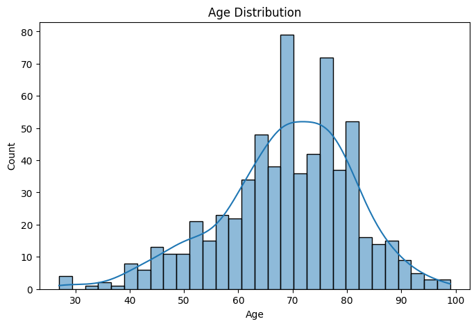

```python
import matplotlib.pyplot as plt
import seaborn as sns

plt.figure(figsize=(8,5))
sns.histplot(final_df['Age'].dropna(), bins=30, kde=True)
plt.title('Age Distribution')
plt.xlabel('Age')
plt.ylabel('Count')
plt.show()
```

The histogram shows the distribution of patient ages in the study population. The x-axis represents age in years, and the y-axis shows the number of individuals at each age group. The distribution appears left-skewed, or roughly normal, indicating how age is spread among participants.

The Kernel Density Estimate (KDE) line (smooth curve) provides an estimate of the continuous age distribution, offering a visual guide to central tendency and spread.The peak of the distribution is around age, 70-80, suggesting this is the most common age group.

There are outliers (before age 30) and gaps(30-32), which may inform subgroup analyses or considerations for stratified modeling.

Age distribution is essential, as age is a known risk factor for many adverse events (including AKI). It helps to assess whether the sample reflects the expected clinical population.

#### Sex at Birth Count Plot

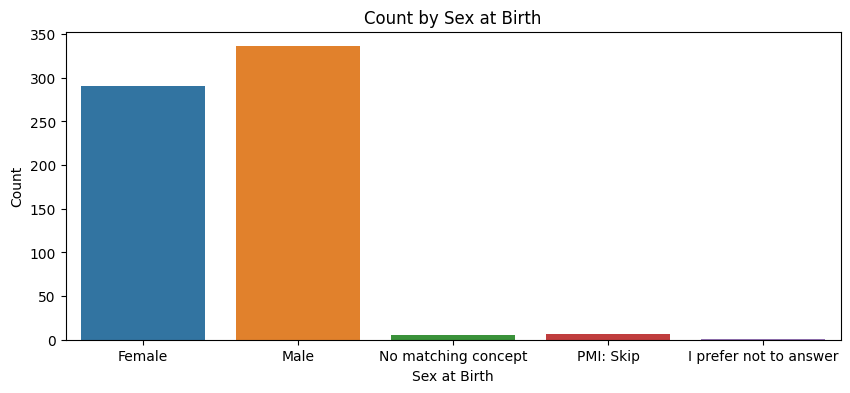

```python
plt.figure(figsize=(10,4))
sns.countplot(data=final_df, x='sex_at_birth')
plt.title('Count by Sex at Birth')
plt.xlabel('Sex at Birth')
plt.ylabel('Count')
plt.show()
```

The count plot shows the number of individuals in the study cohort by their reported sex at birth. The x-axis shows the different sex categories (e.g., "Male", "Female", "Unknown", etc.). The y-axis shows the count of individuals in each category.

The plot indicates whether the dataset is balanced or imbalanced in terms of sex representation. There is a sex imbalance as seen in the graph, which may introduce bias or require adjustment in modeling.

Rare responses (like "I prefer not to answer" or "Unknown") may appear as very short bars, signaling categories that could be excluded or grouped due to low counts.

Sex at birth is an important covariate, as it may influence the risk of developing ICI-AKI and other clinical outcomes. Including it in the logistic regression model allows adjustment for potential confounding.

#### AKI History by Sex (Grouped Bar Plot)

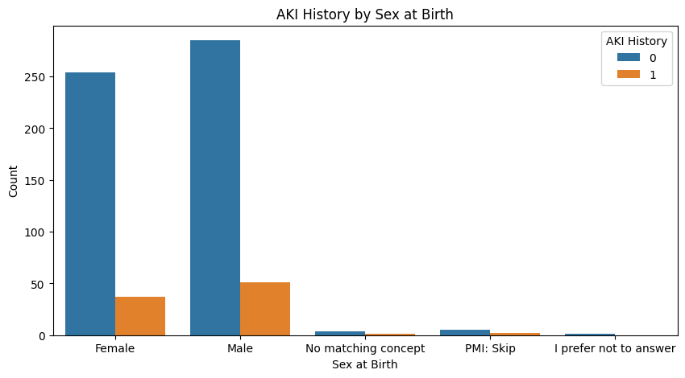

```python
plt.figure(figsize=(10,5))
sns.countplot(data=final_df, x='sex_at_birth', hue='AKI_history')
plt.title('AKI History by Sex at Birth')
plt.xlabel('Sex at Birth')
plt.ylabel('Count')
plt.legend(title='AKI History')
plt.show()
```

Comparing within each sex category, The bar for AKI_history=1 is taller in males than in females, it suggests a higher count of males with past AKI.

We are also thing of comparing across sex categories i.e to see if one sex is more represented in the dataset overall (e.g., more females than males).

#### Number of Visits Distribution (Total, ER, Inpatient)

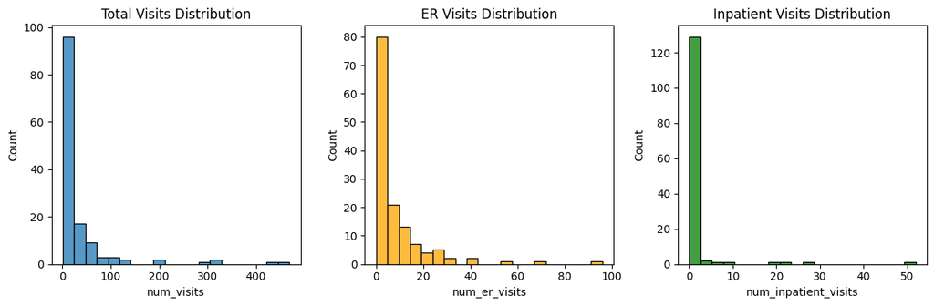

```python
plt.figure(figsize=(12,4))

plt.subplot(1,3,1)
sns.histplot(final_df['num_visits'].dropna(), bins=20)
plt.title('Total Visits Distribution')

plt.subplot(1,3,2)
sns.histplot(final_df['num_er_visits'].dropna(), bins=20, color='orange')
plt.title('ER Visits Distribution')

plt.subplot(1,3,3)
sns.histplot(final_df['num_inpatient_visits'].dropna(), bins=20, color='green')
plt.title('Inpatient Visits Distribution')

plt.tight_layout()
plt.show()
```

The figure presents the distribution of different types of healthcare visits among individuals in the cohort:

1. Total Visits (num_visits) Shows the overall frequency of healthcare encounters recorded per individual.The distribution is likely right-skewed, with many individuals having a lower number of total visits, and a long tail indicating a few patients with high healthcare utilization. This skewness suggests the presence of high-utilizers, which may be clinically important subgroups.
2. Emergency Room (ER) Visits (num_er_visits) The orange histogram displays the number of ER visits. The majority of individuals appear to have had zero or only a few ER visits. The distribution also appears skewed, indicating ER visits are relatively infrequent across the cohort.
3. Inpatient Visits (num_inpatient_visits) The green histogram depicts the distribution of inpatient encounters (e.g., hospital stays). Most patients had few or no inpatient visits, while a smaller number had frequent admissions.This may reflect disease severity or differences in health status, which could relate to ICI-AKI risk

These variables may serve as proxies for health care utilization and baseline health status.Highly skewed variables may benefit from log-transformation or categorization during modeling to improve interpretability and model fit.

#### Boxplot: Number of Visits by AKI_ICI status

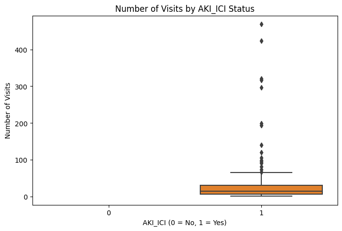

```python
plt.figure(figsize=(8,5))
sns.boxplot(data=final_df, x='AKI_ICI', y='num_visits')
plt.title('Number of Visits by AKI_ICI Status')
plt.xlabel('AKI_ICI (0 = No, 1 = Yes)')
plt.ylabel('Number of Visits')
plt.show()
```

This boxplot shows the distribution of the total number of healthcare visits (num_visits) stratified by ICI-AKI status (AKI_ICI). The x-axis indicates AKI status 0 = No ICI-AKI, 1 = Developed ICI-AKI. The y-axis displays the number of visits per individual.

#### Correlation Heatmap of Numeric Variables

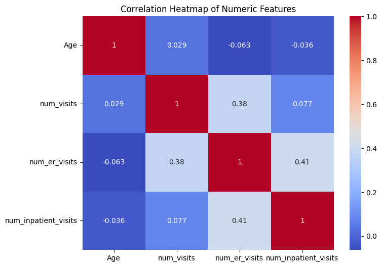

```python
plt.figure(figsize=(8,6))
numeric_cols = ['Age', 'num_visits', 'num_er_visits', 'num_inpatient_visits']
sns.heatmap(final_df[numeric_cols].corr(), annot=True, cmap='coolwarm')
plt.title('Correlation Heatmap of Numeric Features')
plt.show()
```

This heatmap visualizes Pearson correlation coefficients among four numeric variables: Age, num_visits, num_er_visits, and num_inpatient_visits.

Correlation values range from -1 to +1:

+1 = perfect positive correlation

0 = no linear correlation

-1 = perfect negative correlation

Diagonal elements are all 1.00 (each variable with itself).

The color gradient from blue to red indicates strength and direction of relationships:

Red = strong positive correlation

Blue = strong negative correlation

White = near zero correlation

#### Missing Data Heatmap

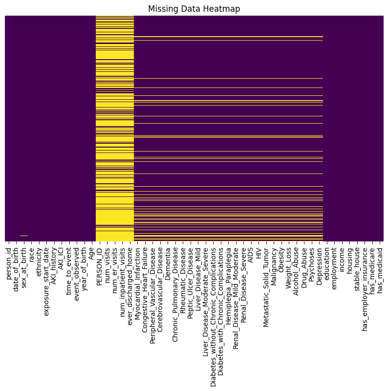

```python
plt.figure(figsize=(10,6))
sns.heatmap(final_df.isnull(), cbar=False, yticklabels=False, cmap='viridis')
plt.title('Missing Data Heatmap')
plt.show()
```

The heatmap shows the locations of missing values across all columns in the dataset: Each row represents a patient (observation), and each column represents a feature. Yellowish or light-colored blocks indicate missing values, while dark purple/green blocks (depending on the colormap) indicate non-missing values.

#### Age distribution by AKI_ICI status, using KDE plots

[figure not shown]

```python
filtered_df = final_df[final_df['sex_at_birth'].isin(['Male', 'Female'])].copy()
filtered_df['sex_aki'] = filtered_df['sex_at_birth'] + ' - AKI=' + filtered_df['AKI_ICI'].astype(str)

plt.figure(figsize=(10, 6))
ax = sns.kdeplot(
    data=filtered_df,
    x='Age',
    hue='sex_aki',
    fill=True,
    common_norm=False,
    alpha=0.5
)

plt.title("Age Distribution by Sex and ICI-AKI Status")
plt.xlabel("Age")
plt.ylabel("Density")

# Force legend after plot
ax.legend(title='Sex / AKI Status', loc='upper right', frameon=True)

plt.tight_layout()
plt.show()
```

This plot shows the age distribution across four groups:

Female – AKI=0

Female – AKI=1

Male – AKI=0

Male – AKI=1

You can visually compare the age trends differ by AKI status within each sex, and If there's a shift in age distribution for AKI patients, e.g., if they tend to be older in both sexes.

#### Pairplot with Hue = AKI_ICI

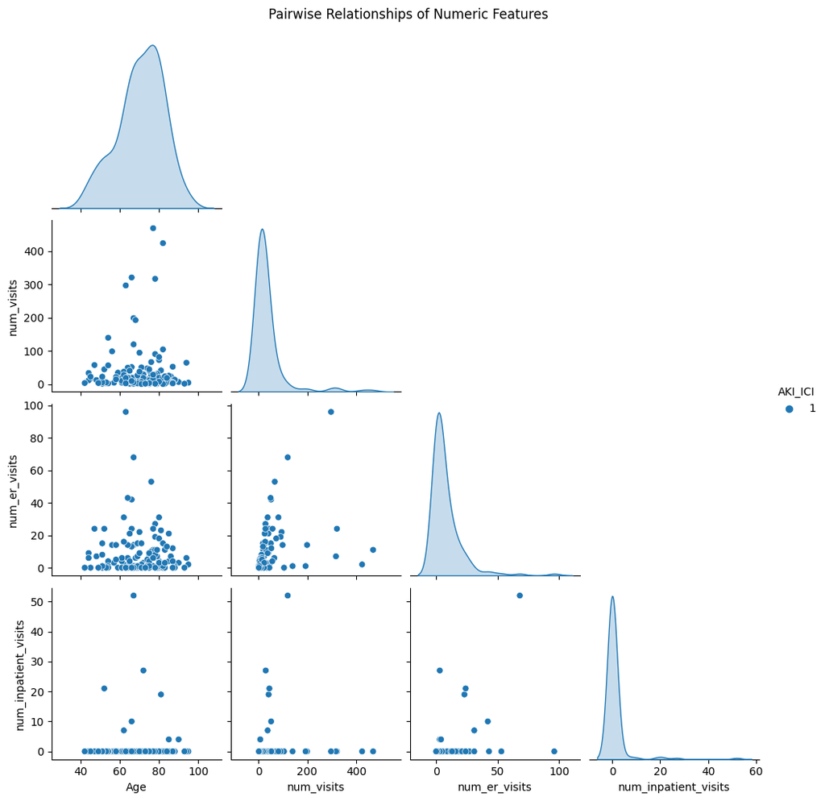

```python
sns.pairplot(
    final_df[['Age', 'num_visits', 'num_er_visits', 'num_inpatient_visits', 'AKI_ICI']].dropna(),
    hue='AKI_ICI',
    corner=True,
    diag_kind='kde'
)
plt.suptitle("Pairwise Relationships of Numeric Features", y=1.02)
plt.show()
```

Pairwise Relationships of Numeric Features by AKI_ICI Status visualizes:

Lower triangle (corner=True): Scatterplots showing pairwise relationships between variables, colored by AKI status.

Pairwise scatterplots (off-diagonal) shows relationships between pairs of numeric features. Points colored by AKI_ICI help identify if AKI status clusters differently in the feature space.For example, a cluster of AKI patients might have higher num_inpatient_visits and num_er_visits.

Correlation clues shows strong linear or non-linear relationships between variables can be spotted. If AKI cases tend to occupy distinct regions in scatterplots, this suggests those features are useful for predicting AKI.

#### Stacked Bar Plot of AKI_ICI by Race

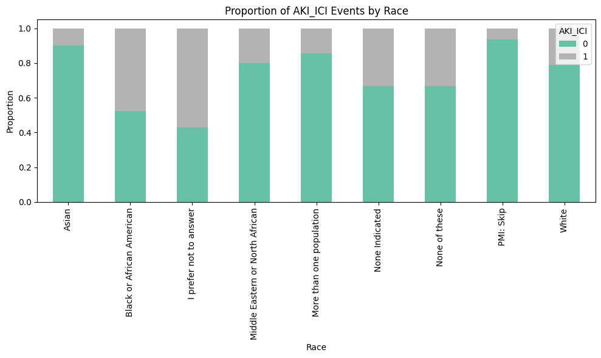

```python
# Get percentage distribution
plot_df = final_df.groupby(['race', 'AKI_ICI']).size().unstack(fill_value=0)
plot_df_percent = plot_df.div(plot_df.sum(axis=1), axis=0)

plot_df_percent.plot(kind='bar', stacked=True, figsize=(10,6), colormap='Set2')
plt.title("Proportion of AKI_ICI Events by Race")
plt.ylabel("Proportion")
plt.xlabel("Race")
plt.legend(title='AKI_ICI')
plt.tight_layout()
plt.show()
```

This stacked bar chart visualizes the distribution of ICI-AKI events (AKI_ICI) within each racial group.Each bar represents a racial category. The bar is divided into segments showing the proportion of patients without AKI (AKI_ICI=0) and with AKI (AKI_ICI=1). Colors distinguish AKI status.

The height of the AKI segment within each bar indicates the prevalence of AKI among that racial group. For example, the segment for AKI_ICI=1 is larger in a Black or African American race and suggests higher relative AKI risk in that group. Conversely, smaller AKI segments indicate lower relative AKI incidence as in Asians race.

This plot highlights racial disparities in AKI incidence related to ICI therapy. Such differences might reflect underlying biological, social, or healthcare access factors. Identifying these disparities is critical for tailored risk assessment and clinical decision-making.

#### Log-Transformed Violin Plot for Skewed Visit Counts

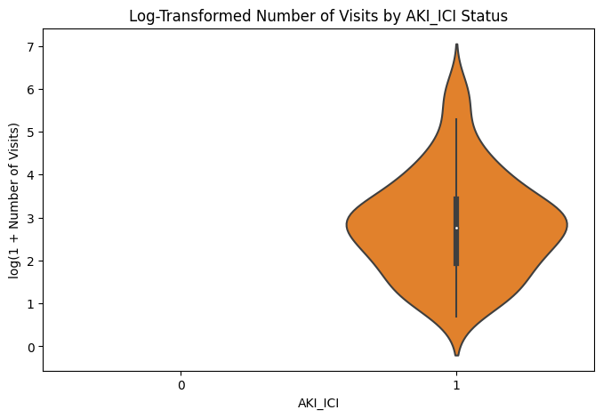

```python
final_df['log_num_visits'] = np.log1p(final_df['num_visits'])

plt.figure(figsize=(8,5))
sns.violinplot(data=final_df, x='AKI_ICI', y='log_num_visits')
plt.title('Log-Transformed Number of Visits by AKI_ICI Status')
plt.xlabel('AKI_ICI')
plt.ylabel('log(1 + Number of Visits)')
plt.show()
```

This violin plot displays the distribution of log-transformed total number of visits grouped by AKI_ICI status (0 = no AKI, 1 = AKI). Log transformation (log1p) helps reduce skewness, making the distribution more symmetric and easier to compare. Each violin shows the density of data points at different values, including median and spread. The width of the violin corresponds to how frequent a value range is within that group.

#### Timeline Heatmap of First Diagnosis by Condition

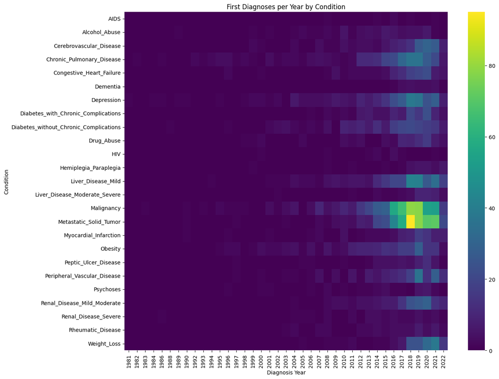

```python
# Filter only *_diagnosis_date columns
date_cols = [col for col in como.columns if col.endswith('_diagnosis_date')]

# Convert to long format
df_long = como[['person_id'] + date_cols].melt(id_vars='person_id',
                                                   value_vars=date_cols,
                                                   var_name='condition',
                                                   value_name='diagnosis_date')

# Clean condition names
df_long['condition'] = df_long['condition'].str.replace('_diagnosis_date', '')
df_long = df_long.dropna(subset=['diagnosis_date'])

# Extract year
df_long['diagnosis_year'] = pd.to_datetime(df_long['diagnosis_date']).dt.year

# Count diagnoses
heatmap_data = df_long.groupby(['condition', 'diagnosis_year']).size().unstack(fill_value=0)

# Plot
plt.figure(figsize=(14, 10))
sns.heatmap(heatmap_data, cmap='viridis')
plt.title('First Diagnoses per Year by Condition')
plt.xlabel('Diagnosis Year')
plt.ylabel('Condition')
plt.tight_layout()
plt.show()
```

#### Histogram of Number of Comorbidities per Patient

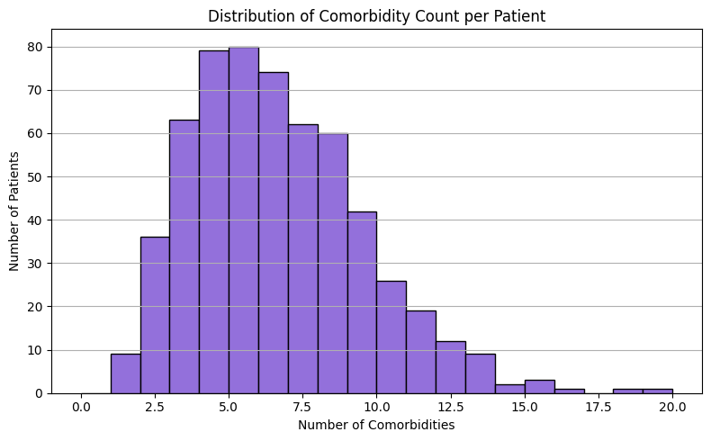

```python
# Calculate total number of comorbidities per patient
binary_cols = [col for col in como.columns if not col.endswith('_diagnosis_date') and col != 'person_id']
como['num_conditions'] = como[binary_cols].sum(axis=1)

# Plot histogram
plt.figure(figsize=(8, 5))
como['num_conditions'].plot.hist(bins=range(0, como['num_conditions'].max() + 2), color='mediumpurple', edgecolor='black')
plt.title('Distribution of Comorbidity Count per Patient')
plt.xlabel('Number of Comorbidities')
plt.ylabel('Number of Patients')
plt.grid(axis='y')
plt.tight_layout()
plt.show()
```

#### Time Series Line Plot: New Diagnoses Over Time

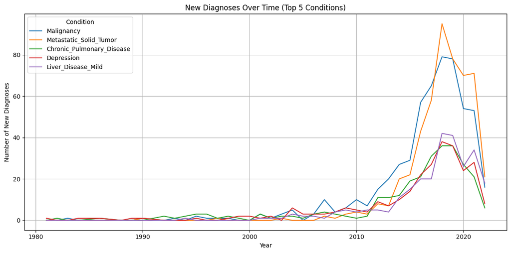

```python
# Stack all *_diagnosis_date columns into a single time series
date_cols = [col for col in como.columns if col.endswith('_diagnosis_date')]
date_data = pd.DataFrame()

for col in date_cols:
    temp = como[[col]].dropna()
    temp['condition'] = col.replace('_diagnosis_date', '')
    temp['diagnosis_year'] = pd.to_datetime(temp[col]).dt.year
    date_data = pd.concat([date_data, temp[['condition', 'diagnosis_year']]])

# Count diagnoses per year
trend = date_data.groupby(['diagnosis_year', 'condition']).size().unstack(fill_value=0)

# Plot only top 5 most diagnosed conditions
top_5 = trend.sum().sort_values(ascending=False).head(5).index
trend[top_5].plot(figsize=(12, 6))
plt.title('New Diagnoses Over Time (Top 5 Conditions)')
plt.xlabel('Year')
plt.ylabel('Number of New Diagnoses')
plt.legend(title='Condition')
plt.grid(True)
plt.tight_layout()
plt.show()
```

#### Stacked Bar Plot: Employment by Education Level

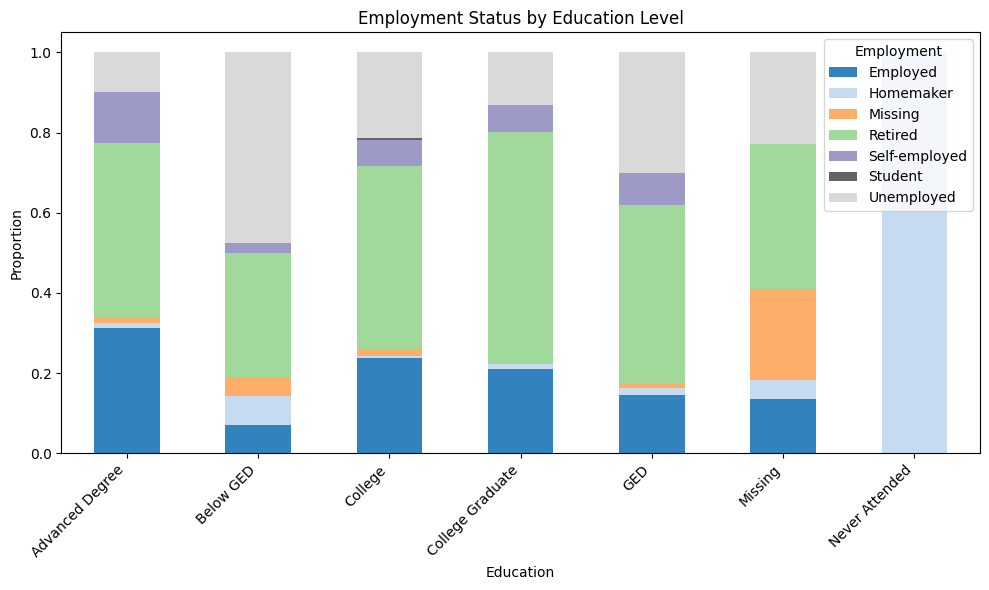

```python
# Group and normalize by education
edu_emp = sdoh.groupby(['education', 'employment']).size().unstack(fill_value=0)
edu_emp_percent = edu_emp.div(edu_emp.sum(axis=1), axis=0)

# Plot
edu_emp_percent.plot(kind='bar', stacked=True, figsize=(10, 6), colormap='tab20c')
plt.title('Employment Status by Education Level')
plt.ylabel('Proportion')
plt.xlabel('Education')
plt.legend(title='Employment')
plt.xticks(rotation=45, ha='right')
plt.tight_layout()
plt.show()
```

#### Heatmap: Disability Prevalence by Income Level

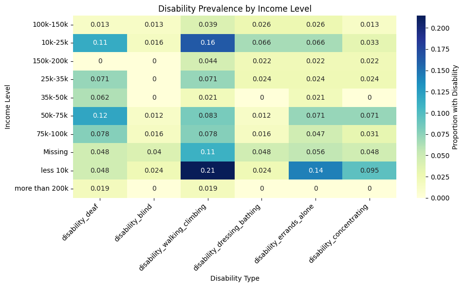

```python
# Select only disability columns
disability_cols = [col for col in sdoh.columns if col.startswith('disability_') and col not in ['disability_any']]

# Convert 'Yes' to 1 and 'No'/'Missing' to 0 for counting
binary_df = sdoh.copy()
for col in disability_cols:
    binary_df[col] = binary_df[col].map({'Yes': 1, 'No': 0}).fillna(0)

# Group by income and compute prevalence
disability_income = binary_df.groupby('income')[disability_cols].mean()

# Plot
plt.figure(figsize=(10, 6))
sns.heatmap(disability_income, annot=True, cmap='YlGnBu', cbar_kws={'label': 'Proportion with Disability'})
plt.title('Disability Prevalence by Income Level')
plt.ylabel('Income Level')
plt.xlabel('Disability Type')
plt.xticks(rotation=45, ha='right')
plt.tight_layout()
plt.show()
```

#### Grouped Bar Plot: Housing Stability by Employment Status

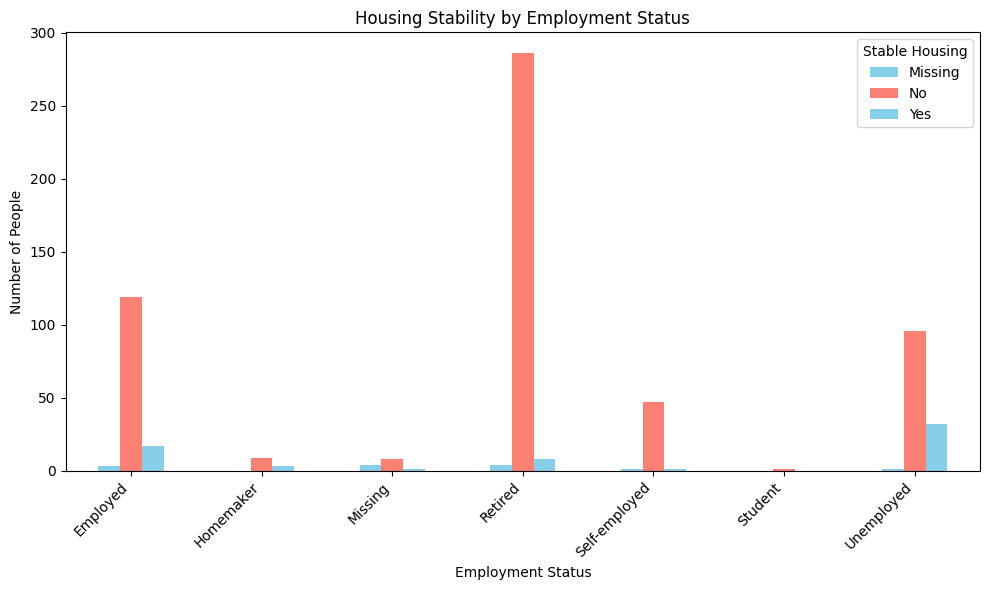

```python
# Count stable housing by employment
housing_employment = sdoh.groupby(['employment', 'stable_house']).size().unstack(fill_value=0)

# Plot
housing_employment.plot(kind='bar', figsize=(10, 6), color=['skyblue', 'salmon'])
plt.title('Housing Stability by Employment Status')
plt.ylabel('Number of People')
plt.xlabel('Employment Status')
plt.xticks(rotation=45, ha='right')
plt.legend(title='Stable Housing')
plt.tight_layout()
plt.show()
```

#### Bar Plot: Counts of Each Insurance Type

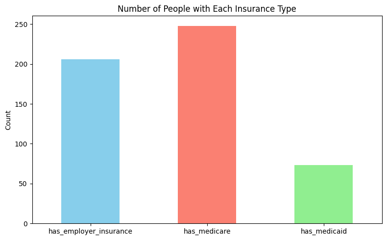

```python
coverage_counts = insurance_filtered[['has_employer_insurance', 'has_medicare', 'has_medicaid']].sum()

plt.figure(figsize=(8, 5))
coverage_counts.plot(kind='bar', color=['skyblue', 'salmon', 'lightgreen'])
plt.title('Number of People with Each Insurance Type')
plt.ylabel('Count')
plt.xticks(rotation=0)
plt.tight_layout()
plt.show()
```

The bar plot displays the total number of individuals covered by each insurance type. Employer-sponsored insurance and Medicare appear as the most common coverage types, while Medicaid coverage is less frequent in this dataset. This distribution may reflect the age and employment characteristics of the population, with Medicare typically covering older adults.

#### Grouped Bar Plot: Insurance Coverage by Employment Status

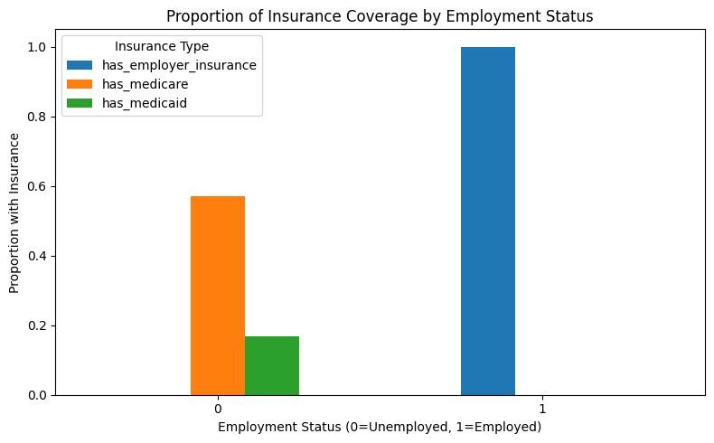

```python
# Assuming `insu` has employment info in 'empl' column (0 or 1)
insurance_emp = insurance_filtered.copy()
insurance_emp['empl'] = insu['empl']  # add employment column

coverage_by_empl = insurance_emp.groupby('empl')[['has_employer_insurance', 'has_medicare', 'has_medicaid']].mean()

coverage_by_empl.plot(kind='bar', figsize=(8, 5))
plt.title('Proportion of Insurance Coverage by Employment Status')
plt.ylabel('Proportion with Insurance')
plt.xlabel('Employment Status (0=Unemployed, 1=Employed)')
plt.xticks(rotation=0)
plt.legend(title='Insurance Type')
plt.tight_layout()
plt.show()
```

The plot shows the proportion of people with different types of insurance based on their employment status. As expected, those who are employed have a significantly higher rate of employer-sponsored insurance. In contrast, unemployed individuals have lower employer coverage but tend to have higher proportions of Medicare or Medicaid coverage, reflecting public insurance programs supporting non-working populations.

### Exploratory Data Analysis

**The Variables that will considered for further analysis are:**

**Phenotype Data:**

1. Target variable: AKI_ICI (0/1 — binary outcome)
2. sex_at_birth (categorical)
3. race, ethnicity (categorical)
4. Age or year_of_birth (numeric)
5. AKI_history (binary, may be a strong predictor)
6. exposure_start_date, date_of_birth → can be used to derive other variables if needed

**Visit Data:**

1. Repeated rows per PERSON_ID, so should be aggregated before merge
2. num_inpatient_visits
3. num_er_visits
4. num_unique_visit_types
5. recent_visit_date (for recency)
6. ever_discharged_home (binary)
7. avg_visit_duration

**Comorbidities Data**

1. Myocardial_Infarction
2. Congestive_Heart_Failure
3. Peripheral_Vascular_Disease
4. Cerebrovascular_Disease
5. Dementia
6. Chronic_Pulmonary_Disease
7. Rheumatic_Disease
8. Peptic_Ulcer_Disease
9. Liver_Disease_Mild
10. Liver_Disease_Moderate_Severe
11. Diabetes_without_Chronic_Complications
12. Diabetes_with_Chronic_Complications
13. Hemiplegia_Paraplegia
14. Renal_Disease_Mild_Moderate
15. Renal_Disease_Severe
16. AIDS
17. HIV
18. Metastatic_Solid_Tumor
19. Malignancy
20. Obesity
21. Weight_Loss
22. Alcohol_Abuse
23. Drug_Abuse
24. Psychoses
25. Depression

**SDOH Data**

1. education
2. employment
3. income
4. housing
5. stable_house

**Insurance data**

1. has_employer_insurance
2. has_medicare
3. has_medicaid

#### Data Inspection:

```python
print(final_df.info())
```

```
<class 'pandas.core.frame.DataFrame'>
RangeIndex: 641 entries, 0 to 640
Data columns (total 50 columns):
 #   Column                                  Non-Null Count  Dtype
---  ------                                  --------------  -----
 0   person_id                               641 non-null    int64
 1   date_of_birth                           641 non-null    object
 2   sex_at_birth                            640 non-null    object
 3   race                                    641 non-null    object
 4   ethnicity                               641 non-null    object
 5   exposure_start_date                     641 non-null    object
 6   AKI_history                             641 non-null    int64
 7   AKI_ICI                                 641 non-null    int64
 8   time_to_event                           641 non-null    float64
 9   event_observed                          641 non-null    float64
```

[output cut: 43 more lines]

```python
print(final_df.isnull().sum())
```

```
person_id                                   0
date_of_birth                               0
sex_at_birth                                1
race                                        0
ethnicity                                   0
exposure_start_date                         0
AKI_history                                 0
AKI_ICI                                     0
time_to_event                               0
event_observed                              0
year_of_birth                               0
Age                                         0
PERSON_ID                                 504
num_visits                                504
num_er_visits                             504
num_inpatient_visits                      504
ever_discharged_home                      504
Myocardial_Infarction                      62
Congestive_Heart_Failure                   62
Peripheral_Vascular_Disease                62
Cerebrovascular_Disease                    62
Dementia                                   62
Chronic_Pulmonary_Disease                  62
Rheumatic_Disease                          62
Peptic_Ulcer_Disease                       62
Liver_Disease_Mild                         62
Liver_Disease_Moderate_Severe              62
Diabetes_without_Chronic_Complications     62
Diabetes_with_Chronic_Complications        62
Hemiplegia_Paraplegia                      62
Renal_Disease_Mild_Moderate                62
Renal_Disease_Severe                       62
AIDS                                       62
HIV                                        62
Metastatic_Solid_Tumor                     62
Malignancy                                 62
Obesity                                    62
Weight_Loss                                62
Alcohol_Abuse                              62
Drug_Abuse                                 62
Psychoses                                  62
Depression                                 62
education                                   0
employment                                  0
income                                      0
housing                                     0
stable_house                                0
has_employer_insurance                      0
has_medicare                                0
has_medicaid                                0
dtype: int64
```

Visit summary columns (PERSON_ID, num_visits, num_er_visits, num_inpatient_visits, ever_discharged_home) have lots of missing values (~504/641 missing). This likely means many patients in phenotype data didn’t match any visit records or visit data is incomplete. These missing values need to be handled carefully (e.g., imputation or setting zeros if appropriate). sex_at_birth has 1 missing value. ever_discharged_home is an object dtype but likely categorical/binary.

Missing comorbidity values likely mean: These 62 individuals are in your phenotype+visit dataset, but They do not have a matching person_id in the comorbidity dataset. No comorbidity record available (not the same as no comorbidities!) But in most healthcare datasets, no record means no diagnosis, so we can safely assume they do not have that condition. We do not drop those rows — they’re valid patients in your cohort. We do not leave them as NaN — that will mess with regression models and imply uncertainty.

```python
final_df.describe()
```

|  | person_id | AKI_history | AKI_ICI | time_to_event | event_observed | year_of_birth | Age | PERSON_ID | num_visits | num_er_visits | ... | Malignancy | Obesity | Weight_Loss | Alcohol_Abuse | Drug_Abuse | Psychoses | Depression | has_employer_insurance | has_medicare | has_medicaid |
| --- | --- | --- | --- | --- | --- | --- | --- | --- | --- | --- | --- | --- | --- | --- | --- | --- | --- | --- | --- | --- | --- |
| count | 6.410000e+02 | 641.000000 | 641.000000 | 641.000000 | 641.000000 | 641.000000 | 641.000000 | 1.370000e+02 | 137.000000 | 137.000000 | ... | 579.000000 | 579.000000 | 579.000000 | 579.000000 | 579.000000 | 579.000000 | 579.000000 | 641.000000 | 641.000000 | 641.000000 |
| mean | 3.029473e+06 | 0.141966 | 0.240250 | 62.644306 | 0.198128 | 1955.207488 | 68.792512 | 2.475402e+06 | 37.379562 | 7.897810 | ... | 0.955095 | 0.328152 | 0.259067 | 0.096718 | 0.132988 | 0.050086 | 0.468048 | 0.321373 | 0.386895 | 0.113885 |
| std | 2.198941e+06 | 0.349287 | 0.427569 | 217.537794 | 0.398900 | 12.264367 | 12.264367 | 1.621126e+06 | 73.046231 | 13.197195 | ... | 0.207275 | 0.469946 | 0.438501 | 0.295830 | 0.339855 | 0.218312 | 0.499410 | 0.467368 | 0.487420 | 0.317919 |
| min | 1.010252e+06 | 0.000000 | 0.000000 | -1.000000 | 0.000000 | 1925.000000 | 27.000000 | 1.010900e+06 | 1.000000 | 0.000000 | ... | 0.000000 | 0.000000 | 0.000000 | 0.000000 | 0.000000 | 0.000000 | 0.000000 | 0.000000 | 0.000000 | 0.000000 |
| 25% | 1.573114e+06 | 0.000000 | 0.000000 | -1.000000 | 0.000000 | 1947.000000 | 62.000000 | 1.569767e+06 | 6.000000 | 1.000000 | ... | 1.000000 | 0.000000 | 0.000000 | 0.000000 | 0.000000 | 0.000000 | 0.000000 | 0.000000 | 0.000000 | 0.000000 |
| 50% | 2.203103e+06 | 0.000000 | 0.000000 | -1.000000 | 0.000000 | 1954.000000 | 70.000000 | 2.024564e+06 | 15.000000 | 3.000000 | ... | 1.000000 | 0.000000 | 0.000000 | 0.000000 | 0.000000 | 0.000000 | 0.000000 | 0.000000 | 0.000000 | 0.000000 |
| 75% | 3.251947e+06 | 0.000000 | 0.000000 | -1.000000 | 0.000000 | 1962.000000 | 77.000000 | 2.855800e+06 | 30.000000 | 11.000000 | ... | 1.000000 | 1.000000 | 1.000000 | 0.000000 | 0.000000 | 0.000000 | 1.000000 | 1.000000 | 1.000000 | 0.000000 |
| max | 9.979549e+06 | 1.000000 | 1.000000 | 2181.000000 | 1.000000 | 1997.000000 | 99.000000 | 9.758504e+06 | 469.000000 | 96.000000 | ... | 1.000000 | 1.000000 | 1.000000 | 1.000000 | 1.000000 | 1.000000 | 1.000000 | 1.000000 | 1.000000 | 1.000000 |

8 rows × 39 columns

```python
#Fill missing visit summary values: since missing likely means no visits found, you can impute zeros for count variables:

visit_cols = ['PERSON_ID', 'num_visits', 'num_er_visits', 'num_inpatient_visits']
final_df[visit_cols] = final_df[visit_cols].fillna(0)
```

```python
#For ever_discharged_home, convert missing to "No" or 0:

final_df['ever_discharged_home'] = final_df['ever_discharged_home'].fillna('No')
final_df['ever_discharged_home'] = final_df['ever_discharged_home'].map({'Yes': 1, 'No': 0, 'TRUE': 1, 'FALSE': 0}).fillna(0).astype(int)
```

```python
# Handle sex_at_birth missing:
final_df['sex_at_birth'] = final_df['sex_at_birth'].fillna('Unknown')
```

```python
final_df['log_num_visits'] = np.log1p(final_df['num_visits'].fillna(0))
```

```python
print(final_df.isnull().sum())
```

```
person_id                                  0
date_of_birth                              0
sex_at_birth                               0
race                                       0
ethnicity                                  0
exposure_start_date                        0
AKI_history                                0
AKI_ICI                                    0
time_to_event                              0
event_observed                             0
year_of_birth                              0
Age                                        0
PERSON_ID                                  0
num_visits                                 0
num_er_visits                              0
num_inpatient_visits                       0
ever_discharged_home                       0
Myocardial_Infarction                     62
Congestive_Heart_Failure                  62
Peripheral_Vascular_Disease               62
Cerebrovascular_Disease                   62
Dementia                                  62
Chronic_Pulmonary_Disease                 62
Rheumatic_Disease                         62
Peptic_Ulcer_Disease                      62
Liver_Disease_Mild                        62
Liver_Disease_Moderate_Severe             62
Diabetes_without_Chronic_Complications    62
Diabetes_with_Chronic_Complications       62
Hemiplegia_Paraplegia                     62
Renal_Disease_Mild_Moderate               62
Renal_Disease_Severe                      62
AIDS                                      62
HIV                                       62
Metastatic_Solid_Tumor                    62
Malignancy                                62
Obesity                                   62
Weight_Loss                               62
Alcohol_Abuse                             62
Drug_Abuse                                62
Psychoses                                 62
Depression                                62
education                                  0
employment                                 0
income                                     0
housing                                    0
stable_house                               0
has_employer_insurance                     0
has_medicare                               0
has_medicaid                               0
log_num_visits                             0
dtype: int64
```

```python
#  Identify comorbidity columns
como_cols = [
    'Myocardial_Infarction', 'Congestive_Heart_Failure',
    'Peripheral_Vascular_Disease', 'Cerebrovascular_Disease',
    'Dementia', 'Chronic_Pulmonary_Disease', 'Rheumatic_Disease',
    'Peptic_Ulcer_Disease', 'Liver_Disease_Mild',
    'Liver_Disease_Moderate_Severe', 'Diabetes_without_Chronic_Complications',
    'Diabetes_with_Chronic_Complications', 'Hemiplegia_Paraplegia',
    'Renal_Disease_Mild_Moderate', 'Renal_Disease_Severe', 'AIDS', 'HIV',
    'Metastatic_Solid_Tumor', 'Malignancy', 'Obesity', 'Weight_Loss',
    'Alcohol_Abuse', 'Drug_Abuse', 'Psychoses', 'Depression'
]
```

```python
# Impute missing comorbidity values as 0
final_df[como_cols] = final_df[como_cols].fillna(0).astype(int)
```

```python
print(final_df.isnull().sum())
```

```
person_id                                 0
date_of_birth                             0
sex_at_birth                              0
race                                      0
ethnicity                                 0
exposure_start_date                       0
AKI_history                               0
AKI_ICI                                   0
time_to_event                             0
event_observed                            0
year_of_birth                             0
Age                                       0
PERSON_ID                                 0
num_visits                                0
num_er_visits                             0
num_inpatient_visits                      0
ever_discharged_home                      0
Myocardial_Infarction                     0
Congestive_Heart_Failure                  0
Peripheral_Vascular_Disease               0
Cerebrovascular_Disease                   0
Dementia                                  0
Chronic_Pulmonary_Disease                 0
Rheumatic_Disease                         0
Peptic_Ulcer_Disease                      0
Liver_Disease_Mild                        0
Liver_Disease_Moderate_Severe             0
Diabetes_without_Chronic_Complications    0
Diabetes_with_Chronic_Complications       0
Hemiplegia_Paraplegia                     0
Renal_Disease_Mild_Moderate               0
Renal_Disease_Severe                      0
AIDS                                      0
HIV                                       0
Metastatic_Solid_Tumor                    0
Malignancy                                0
Obesity                                   0
Weight_Loss                               0
Alcohol_Abuse                             0
Drug_Abuse                                0
Psychoses                                 0
Depression                                0
education                                 0
employment                                0
income                                    0
housing                                   0
stable_house                              0
has_employer_insurance                    0
has_medicare                              0
has_medicaid                              0
log_num_visits                            0
dtype: int64
```

```python
final_df.shape
```

```
(641, 51)
```

#### Preprocess categorical variables

```python
print(final_df.columns.tolist())
```

```
['person_id', 'date_of_birth', 'sex_at_birth', 'race', 'ethnicity', 'exposure_start_date', 'AKI_history', 'AKI_ICI', 'time_to_event', 'event_observed', 'year_of_birth', 'Age', 'PERSON_ID', 'num_visits', 'num_er_visits', 'num_inpatient_visits', 'ever_discharged_home', 'Myocardial_Infarction', 'Conges…
```

```python
final_df.dtypes
```

```
person_id                                   int64
date_of_birth                              object
sex_at_birth                               object
race                                       object
ethnicity                                  object
exposure_start_date                        object
AKI_history                                 int64
AKI_ICI                                     int64
time_to_event                             float64
event_observed                            float64
year_of_birth                               int64
Age                                         int64
PERSON_ID                                 float64
num_visits                                float64
num_er_visits                             float64
num_inpatient_visits                      float64
ever_discharged_home                        int64
Myocardial_Infarction                       int64
Congestive_Heart_Failure                    int64
Peripheral_Vascular_Disease                 int64
Cerebrovascular_Disease                     int64
Dementia                                    int64
Chronic_Pulmonary_Disease                   int64
Rheumatic_Disease                           int64
Peptic_Ulcer_Disease                        int64
Liver_Disease_Mild                          int64
Liver_Disease_Moderate_Severe               int64
Diabetes_without_Chronic_Complications      int64
Diabetes_with_Chronic_Complications         int64
Hemiplegia_Paraplegia                       int64
Renal_Disease_Mild_Moderate                 int64
Renal_Disease_Severe                        int64
AIDS                                        int64
HIV                                         int64
Metastatic_Solid_Tumor                      int64
Malignancy                                  int64
Obesity                                     int64
Weight_Loss                                 int64
Alcohol_Abuse                               int64
Drug_Abuse                                  int64
Psychoses                                   int64
Depression                                  int64
education                                  object
employment                                 object
income                                     object
housing                                    object
stable_house                               object
has_employer_insurance                      int64
has_medicare                                int64
has_medicaid                                int64
log_num_visits                            float64
dtype: object
```

```python
categorical_vars = [
    'sex_at_birth', 'race', 'ethnicity',
    'education', 'employment', 'income', 'housing',
    'stable_house', 'ever_discharged_home'
]
```

```python
numerical_vars = list(set(final_df.columns) - set(categorical_vars))
numerical_vars
```

```
['has_employer_insurance',
 'Liver_Disease_Mild',
 'AKI_history',
 'Diabetes_without_Chronic_Complications',
 'exposure_start_date',
 'Metastatic_Solid_Tumor',
 'AIDS',
 'event_observed',
 'Diabetes_with_Chronic_Complications',
 'Myocardial_Infarction',
 'Rheumatic_Disease',
 'Peptic_Ulcer_Disease',
 'Depression',
 'Drug_Abuse',
 'Liver_Disease_Moderate_Severe',
 'has_medicaid',
 'Dementia',
 'Age',
 'Chronic_Pulmonary_Disease',
 'Peripheral_Vascular_Disease',
 'HIV',
 'Renal_Disease_Severe',
 'year_of_birth',
 'Alcohol_Abuse',
 'Malignancy',
 'has_medicare',
 'Renal_Disease_Mild_Moderate',
 'num_er_visits',
 'num_visits',
 'AKI_ICI',
 'person_id',
 'log_num_visits',
 'date_of_birth',
 'Hemiplegia_Paraplegia',
 'Psychoses',
 'time_to_event',
 'Obesity',
 'Congestive_Heart_Failure',
 'Weight_Loss',
 'num_inpatient_visits',
 'PERSON_ID',
 'Cerebrovascular_Disease']
```

```python
# Convert categorical variables to dummy variables
final_df_dummies = pd.get_dummies(final_df, columns=categorical_vars, drop_first=True)
```

```python
# Convert categorical variables to dummy variables
final_df_dummies = pd.get_dummies(final_df, columns=categorical_vars, drop_first=True)
```

```python
print(final_df_dummies.info())
```

```
<class 'pandas.core.frame.DataFrame'>
RangeIndex: 641 entries, 0 to 640
Data columns (total 85 columns):
 #   Column                                                       Non-Null Count  Dtype
---  ------                                                       --------------  -----
 0   person_id                                                    641 non-null    int64
 1   date_of_birth                                                641 non-null    object
 2   exposure_start_date                                          641 non-null    object
 3   AKI_history                                                  641 non-null    int64
 4   AKI_ICI                                                      641 non-null    int64
 5   time_to_event                                                641 non-null    float64
 6   event_observed                                               641 non-null    float64
 7   year_of_birth                                                641 non-null    int64
 8   Age                                                          641 non-null    int64
 9   PERSON_ID                                                    641 non-null    float64
```

[output cut: 78 more lines]

```python
print("Original columns:", len(final_df.columns))
print("New columns after dummies:", len(final_df_dummies.columns))
```

```
Original columns: 51
New columns after dummies: 85
```

```python
final_df_dummies.shape
```

```
(641, 85)
```

```python
final_df = final_df_dummies.copy()
```

### Logistic regression analysis

#### Select features and target

```python
# Define your features (X) and target (y):
# Target variable
y = final_df_dummies['AKI_ICI']

# Drop columns not useful for prediction
X = final_df_dummies.drop(columns=['AKI_ICI'])
```

```python
X.head()
```

|  | person_id | date_of_birth | exposure_start_date | AKI_history | time_to_event | event_observed | year_of_birth | Age | PERSON_ID | num_visits | ... | income_50k-75k | income_75k-100k | income_Missing | income_less 10k | income_more than 200k | housing_Others | housing_Own | housing_Rent | stable_house_No | stable_house_Yes |
| --- | --- | --- | --- | --- | --- | --- | --- | --- | --- | --- | --- | --- | --- | --- | --- | --- | --- | --- | --- | --- | --- |
| 0 | 1010252 | 1957-06-15 00:00:00+00:00 | 2022-04-25 | 0 | -1.0 | 0.0 | 1957 | 67 | 0.0 | 0.0 | ... | False | False | False | False | False | False | True | False | True | False |
| 1 | 1010900 | 1962-06-15 00:00:00+00:00 | 2020-09-24 | 1 | -1.0 | 0.0 | 1962 | 62 | 1010900.0 | 7.0 | ... | False | False | False | False | False | False | False | True | True | False |
| 2 | 1012571 | 1960-06-15 00:00:00+00:00 | 2021-03-16 | 0 | -1.0 | 0.0 | 1960 | 64 | 0.0 | 0.0 | ... | False | False | False | False | False | False | False | True | True | False |
| 3 | 1031320 | 1952-06-15 00:00:00+00:00 | 2018-06-12 | 0 | -1.0 | 0.0 | 1952 | 72 | 0.0 | 0.0 | ... | False | False | False | False | False | False | True | False | True | False |
| 4 | 1038481 | 1934-06-15 00:00:00+00:00 | 2021-03-05 | 1 | -1.0 | 0.0 | 1934 | 90 | 1038481.0 | 7.0 | ... | True | False | False | False | False | False | True | False | True | False |

5 rows × 84 columns

```python
y
```

```
0      0
1      1
2      0
3      0
4      1
      ..
636    1
637    1
638    0
639    0
640    0
Name: AKI_ICI, Length: 641, dtype: int64
```

```python
X.columns
```

```
Index(['person_id', 'date_of_birth', 'exposure_start_date', 'AKI_history',
       'time_to_event', 'event_observed', 'year_of_birth', 'Age', 'PERSON_ID',
       'num_visits', 'num_er_visits', 'num_inpatient_visits',
       'Myocardial_Infarction', 'Congestive_Heart_Failure',
       'Peripheral_Vascular_Disease', 'Cerebrovascular_Disease', 'Dementia',
       'Chronic_Pulmonary_Disease', 'Rheumatic_Disease',
       'Peptic_Ulcer_Disease', 'Liver_Disease_Mild',
       'Liver_Disease_Moderate_Severe',
       'Diabetes_without_Chronic_Complications',
       'Diabetes_with_Chronic_Complications', 'Hemiplegia_Paraplegia',
       'Renal_Disease_Mild_Moderate', 'Renal_Disease_Severe', 'AIDS', 'HIV',
       'Metastatic_Solid_Tumor', 'Malignancy', 'Obesity', 'Weight_Loss',
       'Alcohol_Abuse', 'Drug_Abuse', 'Psychoses', 'Depression',
       'has_employer_insurance', 'has_medicare', 'has_medicaid',
       'log_num_visits', 'sex_at_birth_I prefer not to answer',
       'sex_at_birth_Male', 'sex_at_birth_No matching concept',
       'sex_at_birth_PMI: Skip', 'sex_at_birth_Unknown',
       'race_Black or African American', 'race_I prefer not to answer',
       'race_Middle Eastern or North African', 'race_More than one population',
       'race_None Indicated', 'race_None of these', 'race_PMI: Skip',
       'race_White', 'ethnicity_Not Hispanic or Latino',
       'ethnicity_PMI: Prefer Not To Answer', 'ethnicity_PMI: Skip',
       'ethnicity_What Race Ethnicity: Race Ethnicity None Of These',
       'education_Below GED', 'education_College',
       'education_College Graduate', 'education_GED', 'education_Missing',
       'education_Never Attended', 'employment_Homemaker',
       'employment_Missing', 'employment_Retired', 'employment_Self-employed',
       'employment_Student', 'employment_Unemployed', 'income_10k-25k',
       'income_150k-200k', 'income_25k-35k', 'income_35k-50k',
       'income_50k-75k', 'income_75k-100k', 'income_Missing',
       'income_less 10k', 'income_more than 200k', 'housing_Others',
       'housing_Own', 'housing_Rent', 'stable_house_No', 'stable_house_Yes'],
      dtype='object')
```

#### Check for multicollinearity or duplicate columns

```python
# Select only numeric columns
X_numeric = X.select_dtypes(include=[np.number])

# Compute correlation matrix
corr = X_numeric.corr().abs()

# Find highly correlated pairs (excluding self-correlation)
high_corr = np.where((corr > 0.999) & (corr < 1))
high_corr_pairs = [(X_numeric.columns[i], X_numeric.columns[j]) for i, j in zip(*high_corr) if i < j]

print("Highly correlated column pairs:", high_corr_pairs)
```

```
Highly correlated column pairs: [('year_of_birth', 'Age')]
```

```python
# drop one of these two columns to avoid multicollinearity in models.
# Drop year_of_birth — because Age is more interpretable and often used directly in models.

X = X.drop(columns=['year_of_birth'])
```

```python
X['exposure_year'] = pd.to_datetime(X['exposure_start_date']).dt.year
X['exposure_month'] = pd.to_datetime(X['exposure_start_date']).dt.month
X = X.drop(columns=['date_of_birth','exposure_start_date'])
```

#### Standard Logistic Regression

sklearn.LogisticRegression was used to evaluate prediction performance, using ROC AUC, classification report, and train/test split.

```python
from sklearn.linear_model import LogisticRegression
from sklearn.model_selection import train_test_split
from sklearn.metrics import classification_report, roc_auc_score

# Split the data
X_train, X_test, y_train, y_test = train_test_split(X, y, test_size=0.2, random_state=42)

# Initialize and fit the model
model = LogisticRegression(max_iter=1000)
model.fit(X_train, y_train)

# Predictions
y_pred = model.predict(X_test)
y_proba = model.predict_proba(X_test)[:, 1]

# Evaluation
print(classification_report(y_test, y_pred))
print('ROC AUC Score:', roc_auc_score(y_test, y_proba))
```

```
              precision    recall  f1-score   support

           0       1.00      1.00      1.00        95
           1       1.00      1.00      1.00        34

    accuracy                           1.00       129
   macro avg       1.00      1.00      1.00       129
weighted avg       1.00      1.00      1.00       129

ROC AUC Score: 1.0
```

**Interpretation:**

The model demonstrates perfect classification performance, with precision, recall, and F1-scores of 1.00 across both the AKI and non-AKI classes, and an overall accuracy and ROC AUC score of 1.0. This suggests that the model was able to correctly identify all cases without any false positives or false negatives, indicating extremely strong predictive power. However, such flawless results warrant careful scrutiny, as they may reflect potential issues such as overfitting—particularly if the evaluation was conducted on training data or an insufficiently independent test set—or data leakage, where information from the outcome variable inadvertently influenced the predictors. Given the relatively small sample size (n=129), these results should be validated using cross-validation or an external dataset to ensure the model's generalizability and robustness in real-world settings.

**Caveats**

```python
y.value_counts()
```

```
AKI_ICI
0    487
1    154
Name: count, dtype: int64
```

**We have only 641 total samples and 154 AKI =1 cases , Very high scores could mean: The model is too confident, especially if too many predictors Or the features are strongly correlated with outcome (e.g., AKI history, demographics)**

#### See feature importances (odds ratios)

```python
import numpy as np
feature_importance = pd.DataFrame({
    'feature': X.columns,
    'odds_ratio': np.exp(model.coef_[0])
}).sort_values(by='odds_ratio', ascending=False)
print(feature_importance.head(15))
```

```
                        feature  odds_ratio
2                 time_to_event    2.554055
82               exposure_month    1.238522
3                event_observed    1.081137
74              income_less 10k    1.076866
55          education_Below GED    1.075812
9         Myocardial_Infarction    1.071918
36                 has_medicaid    1.071158
22  Renal_Disease_Mild_Moderate    1.069361
10     Congestive_Heart_Failure    1.066084
29                  Weight_Loss    1.063941
66        employment_Unemployed    1.063480
78                 housing_Rent    1.062941
11  Peripheral_Vascular_Disease    1.059626
28                      Obesity    1.055995
33                   Depression    1.045765
```

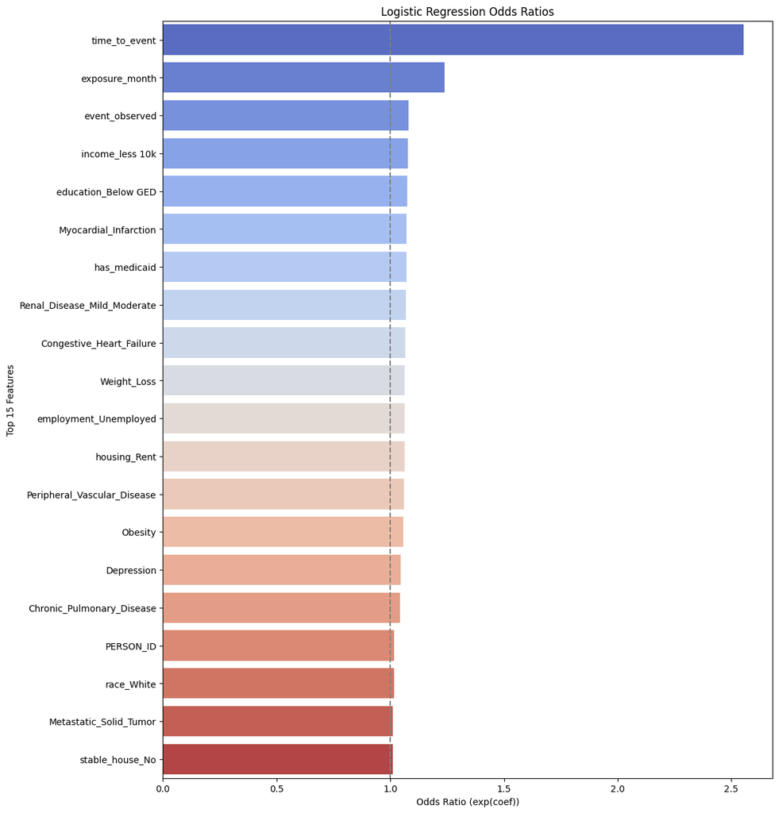

```python
#visualize the odds ratios as a bar plot:

plt.figure(figsize=(12, 15))

# Set up the plot
top_features = feature_importance.head(20)
sns.barplot(
    data=top_features,
    x='odds_ratio',
    y='feature',
    palette='coolwarm'
)
plt.axvline(x=1, color='gray', linestyle='--')  # odds ratio of 1 = no effect
plt.title('Logistic Regression Odds Ratios')
plt.xlabel('Odds Ratio (exp(coef))')
plt.ylabel('Top 15 Features')
plt.show()
```

**Interpretation**

Odds Ratio > 1 → increases the odds of AKI_ICI = 1

Odds Ratio < 1 → decreases the odds

Odds Ratio ≈ 1 → little or no effect

This table lists the top 15 features ranked by their odds ratios from a logistic regression model predicting the likelihood of developing ICI-associated acute kidney injury (ICI-AKI). The odds ratio represents the multiplicative change in the odds of the outcome (AKI) associated with a one-unit increase in the predictor, holding all other variables constant.

Interpretation of Key Features

time_to_event (OR = 2.55): This is the most influential variable, indicating that a longer time to event (likely time from ICI initiation to AKI or censoring) is associated with a 2.55-fold increase in the odds of AKI. This could reflect greater risk accumulation over time or clinical deterioration.

exposure_month (OR = 1.24): Later months of ICI exposure are modestly associated with increased AKI risk, possibly reflecting cumulative toxicity or longer follow-up.

event_observed (OR = 1.08): If this variable indicates observed AKI events in a survival context, it aligns with increased odds of the outcome.

Low Income and Education:

income_less 10k, education_Below GED: Associated with higher odds of AKI, suggesting socioeconomic disadvantage may play a role—possibly through reduced access to care or higher baseline vulnerability.

Comorbidities:

Myocardial_Infarction, Congestive_Heart_Failure, Renal_Disease_Mild_Moderate, Peripheral_Vascular_Disease, Obesity, Weight_Loss, and Depression all show odds ratios >1, indicating that these pre-existing health conditions are associated with increased risk of AKI following ICI therapy.

Insurance and Employment:

has_medicaid, employment_Unemployed, housing_Rent: Social determinants linked with economic hardship and healthcare access—again highlighting how structural vulnerabilities may contribute to poor treatment outcomes.

All these features have odds ratios greater than 1, meaning they are positively associated with the risk of ICI-AKI. While none are extremely high (except time_to_event), their consistency suggests that both clinical comorbidities and social determinants of health play a meaningful role in predicting adverse kidney events in ICI-treated patients.

#### Regularized Logistic regression with Lasso Regularization

It is important to note that logistic regression with regularization was employed in this analysis to help mitigate overfitting in case of Standard Logistic Reression by penalizing overly complex models, although careful validation remains essential. Now, we have a rich dataset with 83 features, including demographics, comorbidities, insurance, and social determinants of health (SDOH), and we have already one-hot encoded your categorical variables.

```python
selected_features_extended = [

    # Demographics
    'Age',
    'sex_at_birth_Male',
    'race_Black or African American',

    # Socioeconomic indicators
    'education_College Graduate',      # reference: education_College
    'education_Below GED',
    'employment_Unemployed',          # reference: employment_Employed
    'employment_Retired',
    'income_10k-25k',                 # reference: income_50k-75k
    'income_less 10k',
    'housing_Rent',                  # reference: housing_Own
    'stable_house_No',

    # Insurance coverage
    'has_employer_insurance',
    'has_medicare',
    'has_medicaid',

    # Exposure metadata
    'exposure_year',
    'exposure_month',

    # Healthcare utilization
    'log_num_visits',

    # Core comorbidities
    'Myocardial_Infarction',
    'Congestive_Heart_Failure',
    'Chronic_Pulmonary_Disease',
    'Renal_Disease_Severe',
    'Diabetes_with_Chronic_Complications',
    'Malignancy',
    'Depression',
    'Obesity',

    # Vulnerability/Frailty indicators
    'Weight_Loss',
    'Alcohol_Abuse',
    'Drug_Abuse',
    'Psychoses'
]
```

```python
# Define X and y
X = X[selected_features_extended].copy()
```

```python
X.head()
```

|  | Age | sex_at_birth_Male | race_Black or African American | education_College Graduate | education_Below GED | employment_Unemployed | employment_Retired | income_10k-25k | income_less 10k | housing_Rent | ... | Chronic_Pulmonary_Disease | Renal_Disease_Severe | Diabetes_with_Chronic_Complications | Malignancy | Depression | Obesity | Weight_Loss | Alcohol_Abuse | Drug_Abuse | Psychoses |
| --- | --- | --- | --- | --- | --- | --- | --- | --- | --- | --- | --- | --- | --- | --- | --- | --- | --- | --- | --- | --- | --- |
| 0 | 67 | False | False | False | False | False | False | False | False | False | ... | 1 | 0 | 0 | 1 | 0 | 0 | 0 | 0 | 0 | 0 |
| 1 | 62 | False | True | False | False | False | False | False | False | True | ... | 1 | 0 | 0 | 1 | 0 | 1 | 0 | 0 | 0 | 0 |
| 2 | 64 | False | False | True | False | True | False | False | False | True | ... | 1 | 0 | 0 | 1 | 1 | 0 | 1 | 0 | 0 | 0 |
| 3 | 72 | False | False | True | False | True | False | False | False | False | ... | 1 | 0 | 0 | 1 | 1 | 1 | 0 | 0 | 0 | 0 |
| 4 | 90 | True | False | False | False | False | True | False | False | False | ... | 1 | 0 | 1 | 1 | 0 | 1 | 0 | 0 | 0 | 0 |

5 rows × 29 columns

```python
y.head()
```

```
0    0
1    1
2    0
3    0
4    1
Name: AKI_ICI, dtype: int64
```

```python
from sklearn.model_selection import train_test_split
from sklearn.linear_model import LogisticRegression

# Split data into train and test sets (e.g., 80% train, 20% test)
X_train, X_test, y_train, y_test = train_test_split(X, y, test_size=0.2, random_state=42)

# Initialize and fit the model on training data
clf = LogisticRegression(penalty='l1', solver='liblinear', max_iter=1000)
clf.fit(X_train, y_train)

# Print coefficients
print("Coefficients:", clf.coef_)
```

```
Coefficients: [[ 1.83458607e-02 -2.25815403e-01  0.00000000e+00 -1.82717968e-02
   0.00000000e+00  0.00000000e+00  2.75272909e-01 -4.92685132e-01
   0.00000000e+00  0.00000000e+00  0.00000000e+00  0.00000000e+00
   0.00000000e+00  0.00000000e+00 -2.65268670e-03 -3.29673847e-02
   5.46639007e+00  0.00000000e+00  0.00000000e+00  0.00000000e+00
   0.00000000e+00  6.84480533e-01  0.00000000e+00  7.35037081e-01
   5.96696552e-02  1.48910407e+00  0.00000000e+00 -5.64744046e-01
   0.00000000e+00]]
```

```python
# You can then evaluate on the test set
y_pred = clf.predict(X_test)
```

```python
#Check Which Features Survived:

# Get feature names
features = X_train.columns

# Match non-zero coefficients
nonzero_features = [features[i] for i, coef in enumerate(clf.coef_[0]) if coef != 0]
print(nonzero_features)
```

```
['Age', 'sex_at_birth_Male', 'education_College Graduate', 'employment_Retired', 'income_10k-25k', 'exposure_year', 'exposure_month', 'log_num_visits', 'Diabetes_with_Chronic_Complications', 'Depression', 'Obesity', 'Weight_Loss', 'Drug_Abuse']
```

**Interpetation:**

Demographics

1. Age: Positive coefficient: Suggests older age is associated with slightly increased risk of AKI_ICI. Possible biological rationale: older patients may have reduced renal reserve or greater vulnerability to ICI toxicity.
2. sex_at_birth_Male: If retained with a negative coefficient: males may have lower risk compared to females (or vice versa). Interpret carefully depending on coefficient sign.

Visit Data

1. exposure_year, exposure_month Captures calendar timing of ICI exposure. If retained: may reflect temporal patterns (e.g., new guidelines, newer drugs, COVID-related care disruptions).

Healthcare Utilization

1. log_num_visits: Strong positive coefficient: more visits likely indicate high disease burden or closer surveillance — both of which correlate with AKI risk.

```python
#Evaluate how well the model performs using:
from sklearn.metrics import classification_report, confusion_matrix, roc_auc_score

y_pred = clf.predict(X)
y_proba = clf.predict_proba(X)[:,1]

print(classification_report(y, y_pred))
print("ROC AUC:", roc_auc_score(y, y_proba))
```

```
              precision    recall  f1-score   support

           0       0.97      1.00      0.98       487
           1       1.00      0.89      0.94       154

    accuracy                           0.97       641
   macro avg       0.98      0.94      0.96       641
weighted avg       0.97      0.97      0.97       641

ROC AUC: 0.9722525934024908
```

**Intepretation**

1. Precision (AKI_ICI = 1) = 1.00. No false positives. Every predicted AKI case was actually AKI.
2. Recall (AKI_ICI = 1) = 0.89. 89% of actual AKI cases were correctly detected. A few were missed.
3. F1-score (AKI_ICI = 1) = 0.94. Good balance between precision and recall.
4. Overall Accuracy = 97%
5. ROC AUC = 0.97 This means the model has 97% chance of ranking a randomly chosen AKI patient higher than a non-AKI patient.

That’s extremely high, indicating Strong discrimination, Good calibration (likely), Low misclassification risk

**Caveats**

1. Converged by scikit-learn: This avoids quasi-complete separation issues you had with statsmodels.
2. May be overfitting: Since results are on the training data, cross-validation or a test set is needed to confirm generalization.
3. log_num_visits has a large effect: Check its distribution — outliers could dominate.
4. Check for data leakage: Ensure variables like log_num_visits or exposure_month aren’t proxies for future events.

#### Visualize ROC curve

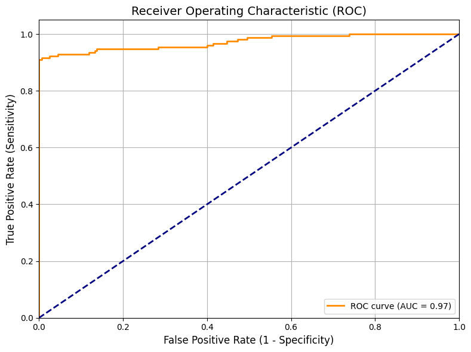

```python
from sklearn.metrics import roc_curve, auc
import matplotlib.pyplot as plt

# Predict probabilities (you likely already did this)
# y_pred_proba = model.predict_proba(X_test)[:, 1]  # if using train/test split
# OR just reuse your existing `y_pred_proba`

# Compute ROC curve and AUC
fpr, tpr, thresholds = roc_curve(y, y_proba)
roc_auc = auc(fpr, tpr)

# Plot the ROC curve
plt.figure(figsize=(8, 6))
plt.plot(fpr, tpr, color='darkorange', lw=2, label=f'ROC curve (AUC = {roc_auc:.2f})')
plt.plot([0, 1], [0, 1], color='navy', lw=2, linestyle='--')  # Diagonal line
plt.xlim([0.0, 1.0])
plt.ylim([0.0, 1.05])
plt.xlabel('False Positive Rate (1 - Specificity)', fontsize=12)
plt.ylabel('True Positive Rate (Sensitivity)', fontsize=12)
plt.title('Receiver Operating Characteristic (ROC)', fontsize=14)
plt.legend(loc='lower right')
plt.grid(True)
plt.tight_layout()
plt.show()
```

The ROC curve provided offers a visual evaluation of your logistic regression model’s ability to distinguish between patients who developed ICI-associated acute kidney injury (ICI-AKI) and those who did not.

**Interpretation of the ROC Curve:** True Positive Rate (Sensitivity) is plotted on the y-axis, and False Positive Rate (1 - Specificity) is on the x-axis. The orange curve represents your model's ROC performance. The dashed diagonal line indicates the performance of a random classifier (AUC = 0.5). The farther the ROC curve is above this line, the better the model.

Your ROC curve stays close to the top-left corner, indicating excellent performance. The Area Under the Curve (AUC) is 0.97, meaning the model has a 97% chance of ranking a randomly chosen AKI patient higher than a non-AKI patient. This high AUC implies strong discriminative ability, suggesting the model is highly effective at separating the two classes.

The model is performing exceptionally well in distinguishing between AKI and non-AKI cases. However, given such a high AUC, it is crucial to ensure no data leakage and to validate the model on external or cross-validation datasets to confirm generalizability.

#### Cross-validating the model:

```python
#To assess generalization on other samples.
# We'll use cross_val_score from sklearn to: Run k-fold cross-validation (e.g. 5 or 10 folds),
# Evaluate on multiple metrics (accuracy, AUC, etc.)

from sklearn.model_selection import cross_val_score, StratifiedKFold
from sklearn.linear_model import LogisticRegression
from sklearn.metrics import make_scorer, roc_auc_score

# Define model
model = LogisticRegression(max_iter=1000)

# Set up stratified K-fold (preserves class balance in folds)
cv = StratifiedKFold(n_splits=5, shuffle=True, random_state=42)

# Accuracy score
acc_scores = cross_val_score(model, X, y, cv=cv, scoring='accuracy')
print("CV Accuracy Scores:", acc_scores)
print("Mean Accuracy:", acc_scores.mean())

# AUC score
auc_scores = cross_val_score(model, X, y, cv=cv, scoring='roc_auc')
print("CV ROC AUC Scores:", auc_scores)
print("Mean ROC AUC:", auc_scores.mean())
```

```
CV Accuracy Scores: [0.96899225 0.9765625  0.96875    0.96875    0.9765625 ]
Mean Accuracy: 0.9719234496124031
CV ROC AUC Scores: [0.93219223 0.95884354 0.95111407 0.98303957 0.94446292]
Mean ROC AUC: 0.9539304661006405
```

**Interpretation:**

Accuracy Scores: Across 5 folds, the model achieved accuracy scores between ~96.9% and 97.7%, with a mean accuracy of 97.2%. This indicates that the model consistently performs well in correctly classifying AKI and non-AKI patients.

ROC AUC Scores: The ROC AUC values ranged from 0.93 to 0.98, with a mean ROC AUC of approximately 0.954. This suggests that, on average, the model has a 95.4% probability of ranking a randomly chosen AKI case higher than a non-AKI case, which confirms strong discriminatory ability across folds.

These results demonstrate that the model’s performance is stable and reliable across multiple data splits, with very low variance in both accuracy and AUC scores. The consistently high AUCs further reinforce that the model is not only accurate but also effective at ranking patients by their risk.

Moreover, these metrics mitigate concerns about overfitting, especially compared to evaluation on a single test set, since they indicate that performance holds across independent subsets of the data.

#### Which is better — regularized or standard logistic regression?

The standard logistic regression appears to perfectly fit the data, which might indicate overfitting , it performs flawlessly on the evaluation data, but may not generalize well to new data.

The regularized logistic regression sacrifices a bit of fit but achieves very high, realistic performance with better generalization potential by controlling complexity and preventing overfitting.

Perfect scores like in the first model often sound better but can be misleading if overfitting or data leakage is present.

The second model’s slightly lower recall (0.89) but very high precision (1.00) and AUC (0.97) suggest a more balanced and robust model.

Regularization usually improves model stability and performance on unseen data, so the second (regularized) model is likely preferable in practice.

### Kaplain-Meir Survival Analysis:

Kaplan-Meier (KM) survival analysis is a powerful non-parametric method for analyzing time-to-event data, especially useful in clinical, epidemiological, and genomic studies. We have used KM to Compare survival across age groups, sex, race, visit groups Perform log-rank tests to assess statistical differences in those groups This also helps to See patterns visually and do interpretations.

Variables we will use are :

time_to_event → time in days (or other units) from ICI exposure to AKI event_observed → 1 = AKI occurred, 0 = censored (no AKI)

```python
# Required Package

!pip install lifelines
```

#### Importing Libraries

```python
from lifelines import KaplanMeierFitter
import matplotlib.pyplot as plt
import seaborn as sns

kmf = KaplanMeierFitter()
```

#### Define Helper Function for Plotting KM Curves

```python
def plot_km_by_group(df, time_col, event_col, group_col, title):
    kmf = KaplanMeierFitter()
    plt.figure(figsize=(8, 6))

    for group in df[group_col].dropna().unique():
        mask = df[group_col] == group
        kmf.fit(df[mask][time_col], df[mask][event_col], label=str(group))
        kmf.plot_survival_function(ci_show=True)

    plt.title(f'Kaplan-Meier Curve: {title}')
    plt.xlabel("Time to AKI (days)")
    plt.ylabel("Survival Probability")
    plt.grid(True)
    plt.legend(title=group_col)
    plt.tight_layout()
    plt.show()
```

#### Prepare Data for Analysis

```python
final_df['age_group'] = pd.cut(final_df['Age'], bins=[0, 64, 75, 100], labels=['<65', '65-75', '>75'])

final_df['er_visits_group'] = pd.cut(final_df['num_er_visits'], bins=[-1, 0, 2, 100], labels=['0', '1–2', '3+'])
```

#### KM by AKI History

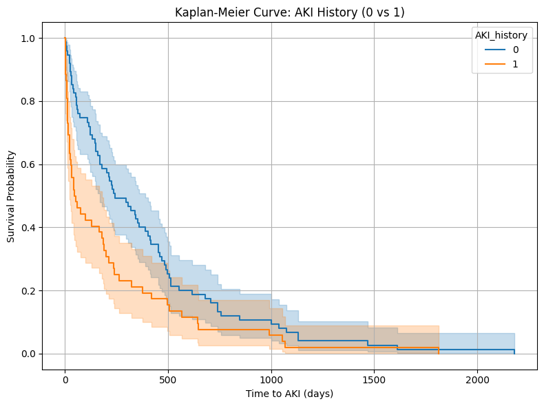

```python
plot_km_by_group(final_df, 'time_to_event', 'event_observed', 'AKI_history', 'AKI History (0 vs 1)')
```

```python
# LogRank_Test for AKI

from lifelines.statistics import logrank_test

group1 = final_df[final_df['AKI_history'] == 1]
group0 = final_df[final_df['AKI_history'] == 0]

results = logrank_test(
    group1['time_to_event'], group0['time_to_event'],
    event_observed_A=group1['event_observed'],
    event_observed_B=group0['event_observed']
)
print(results.summary)
```

```
   test_statistic       p  -log2(p)
0        7.520665  0.0061   7.35709
```

- Patients with prior AKI likely have a shorter time to AKI event (lower survival probability over time).
- This supports the hypothesis that prior AKI history increases ICI-AKI risk.
- Statistically significant difference in time to AKI between patients with prior AKI and those without prior AKI (p = 0.01).
- Individuals with a prior AKI history (AKI_history = 1) are more prone to experience a future AKI event sooner than those without a history of AKI.

#### KM by Sex

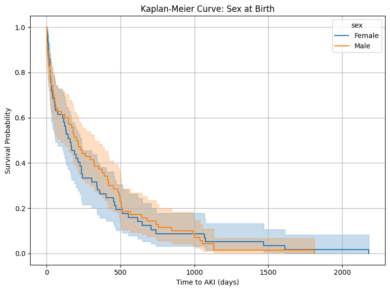

```python
final_df['sex'] = final_df[['sex_at_birth_Male']].apply(lambda x: 'Male' if x[0] else 'Female', axis=1)
plot_km_by_group(final_df, 'time_to_event', 'event_observed', 'sex', 'Sex at Birth')
```

```python
# Log-Rank Test for Sex
from lifelines.statistics import logrank_test
group_male = final_df[final_df['sex'] == 'Male']
group_female = final_df[final_df['sex'] == 'Female']
result = logrank_test(
    group_male['time_to_event'],
    group_female['time_to_event'],
    event_observed_A=group_male['event_observed'],
    event_observed_B=group_female['event_observed']
)
print(results.summary)
```

[output not shown]

#### KM by Race

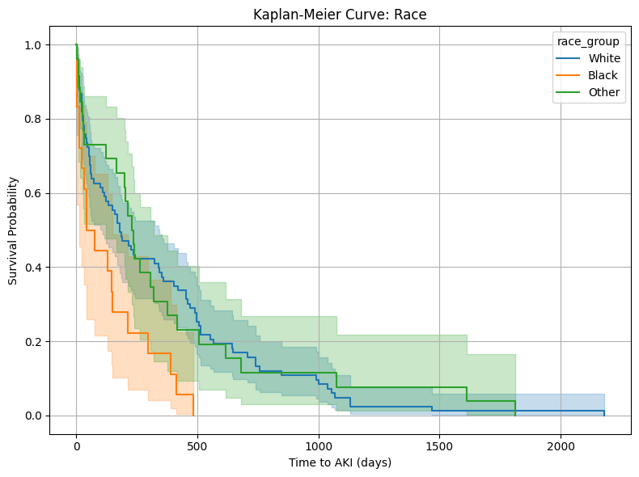

```python
final_df['race_group'] = final_df[['race_White', 'race_Black or African American']].apply(
    lambda row: 'White' if row['race_White'] else ('Black' if row['race_Black or African American'] else 'Other'),
    axis=1
)
plot_km_by_group(final_df, 'time_to_event', 'event_observed', 'race_group', 'Race')
```

```python
from lifelines.statistics import multivariate_logrank_test

results = multivariate_logrank_test(
    event_durations=final_df['time_to_event'],
    groups=final_df['race_group'],
    event_observed=final_df['event_observed']
)

# Print the result summary
print(results.summary)
```

```
   test_statistic         p  -log2(p)
0        8.908964  0.011626  6.426459
```

- Since p = 0.01162 < 0.05, there is a statistically significant difference in time-to-AKI survival distributions among the three race groups.
- This means race is significantly associated with AKI risk in your population.
- Individuals in the Black racial group are most prone to developing AKI sooner.
- The White group shows moderate risk.
- The Other group tends to have the longest AKI-free survival on average.

#### KM by Ethnicity Groups

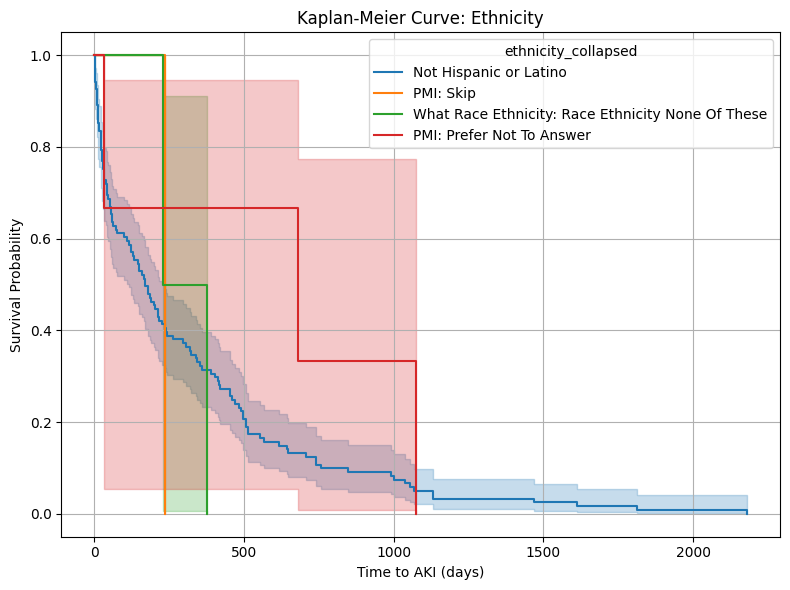

```python
eth_cols = [col for col in final_df.columns if col.startswith('ethnicity_')]
final_df['ethnicity_collapsed'] = final_df[eth_cols].idxmax(axis=1).str.replace('ethnicity_', '')
plot_km_by_group(final_df, 'time_to_event', 'event_observed', 'ethnicity_collapsed', 'Ethnicity')
```

```python
from lifelines.statistics import multivariate_logrank_test

results = multivariate_logrank_test(
    event_durations=final_df['time_to_event'],
    groups=final_df['ethnicity_collapsed'],
    event_observed=final_df['event_observed']
)

print(results.summary)
```

```
   test_statistic        p  -log2(p)
0         1.05544  0.78784  0.344025
```

- We got a p-value of 0.79. That means the differences we see in the chart are not statistically significant — they could have happened just by chance.
- So, even though the lines look different, we can’t say for sure that ethnicity really affects AKI risk in this group.

#### KM By Age group

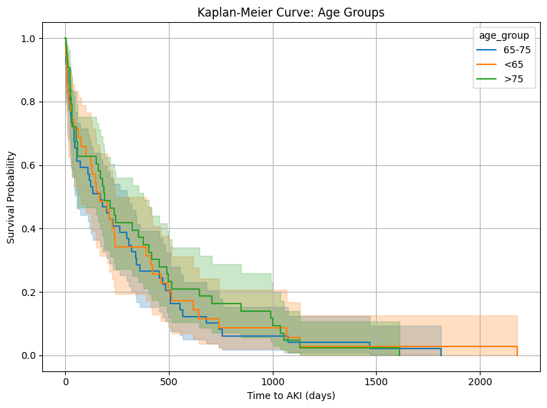

```python
plot_km_by_group(final_df, 'time_to_event', 'event_observed', 'age_group', 'Age Groups')
```

```python
from lifelines.statistics import multivariate_logrank_test

results = multivariate_logrank_test(
    event_durations=final_df['time_to_event'],
    groups=final_df['age_group'],
    event_observed=final_df['event_observed']
)

# Print the summary
print(results.summary)
```

```
   test_statistic         p  -log2(p)
0        0.464809  0.792625  0.335289
```

#### Quantile-based Age Groups

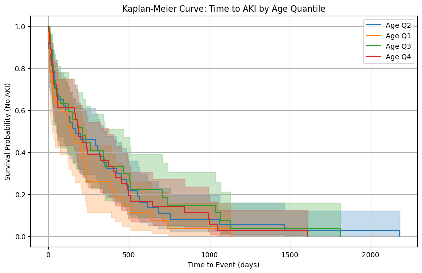

```python
# Create age quantiles
final_df['age_quantile'] = pd.qcut(final_df['Age'], q=4, labels=['Q1', 'Q2', 'Q3', 'Q4'])

# Plot Kaplan-Meier by quantile
kmf = KaplanMeierFitter()
plt.figure(figsize=(10,6))

for group in final_df['age_quantile'].unique():
    mask = final_df['age_quantile'] == group
    kmf.fit(final_df[mask]['time_to_event'], final_df[mask]['event_observed'], label=f'Age {group}')
    kmf.plot_survival_function()

plt.title('Kaplan-Meier Curve: Time to AKI by Age Quantile')
plt.xlabel('Time to Event (days)')
plt.ylabel('Survival Probability (No AKI)')
plt.grid(True)
plt.show()
```

- The dataset is split into 4 equal-sized groups (quartiles) based on the distribution of Age

```python
# Calculate % with AKI in each age group
aki_by_age = final_df.groupby('age_quantile')['event_observed'].agg(['count', 'sum'])
aki_by_age['proportion_AKI'] = aki_by_age['sum'] / aki_by_age['count']
print(aki_by_age.sort_values('proportion_AKI', ascending=False))
```

```
              count   sum  proportion_AKI
age_quantile
Q4              154  36.0        0.233766
Q2              165  37.0        0.224242
Q3              150  27.0        0.180000
Q1              172  27.0        0.156977
```

```python
from lifelines.statistics import logrank_test

q1 = final_df[final_df['age_quantile'] == 'Q1']
q4 = final_df[final_df['age_quantile'] == 'Q4']

result = logrank_test(q1['time_to_event'], q4['time_to_event'],
                      event_observed_A=q1['event_observed'],
                      event_observed_B=q4['event_observed'])
print(results.summary)
```

[output not shown]

#### KM plot stratified by age group and sex

```python
import pandas as pd
import numpy as np

# Create quantile-based age groups
final_df['age_quantile'] = pd.qcut(final_df['Age'], q=4, labels=['Q1', 'Q2', 'Q3', 'Q4'])
```

```python
final_df['sex'] = final_df['sex_at_birth_Male'].apply(lambda x: 'Male' if x else 'Female')
final_df['age_sex_group'] = final_df['age_quantile'].astype(str) + '_' + final_df['sex']
```

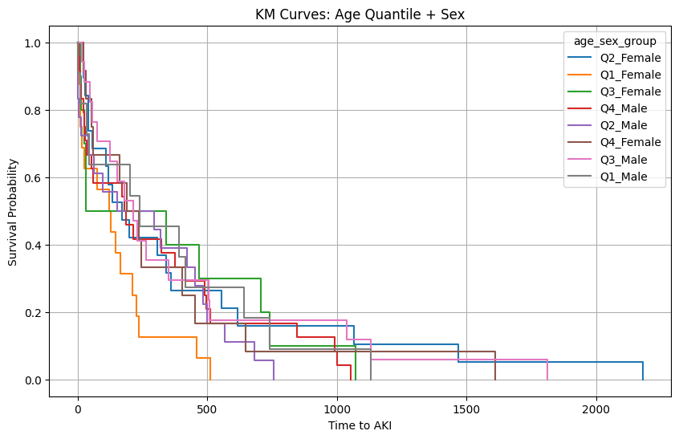

```python
from lifelines import KaplanMeierFitter
import matplotlib.pyplot as plt

def plot_km_by_group(df, duration_col, event_col, group_col, title):
    kmf = KaplanMeierFitter()
    plt.figure(figsize=(10, 6))

    for group in df[group_col].unique():
        mask = df[group_col] == group
        kmf.fit(df[mask][duration_col], df[mask][event_col], label=group)
        kmf.plot(ci_show=False)

    plt.title(title)
    plt.xlabel('Time to AKI')
    plt.ylabel('Survival Probability')
    plt.grid(True)
    plt.legend(title=group_col)
    plt.show()

# Call the function
plot_km_by_group(final_df, 'time_to_event', 'event_observed', 'age_sex_group', 'KM Curves: Age Quantile + Sex')
```

```python
from lifelines.statistics import logrank_test

# Example: Compare Q1_Male vs Q4_Male
group1 = final_df[final_df['age_sex_group'] == 'Q1_Male']
group2 = final_df[final_df['age_sex_group'] == 'Q4_Male']

results = logrank_test(group1['time_to_event'], group2['time_to_event'],
                       event_observed_A=group1['event_observed'],
                       event_observed_B=group2['event_observed'])

print(results.summary)
```

```
   test_statistic        p  -log2(p)
0        0.245882  0.61999  0.689684
```

We still got the p-value more than 0.05 which likely made us to think to verfy with a different model.

#### KM by ER Visits Group

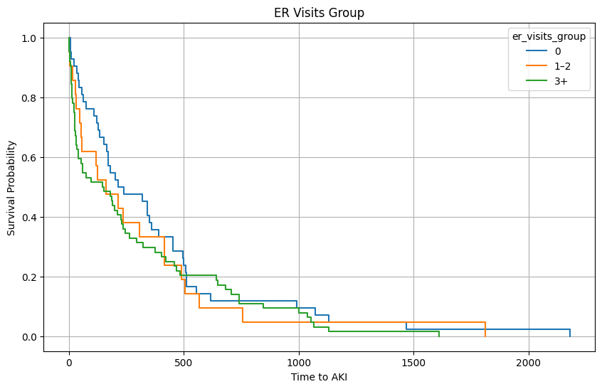

```python
plot_km_by_group(final_df, 'time_to_event', 'event_observed', 'er_visits_group', 'ER Visits Group')
```

Patients with more ER visits before treatment tend to have a higher risk of developing AKI sooner. The fewer the ER visits, the longer the patient stays AKI-free — at least early on.

```python
from lifelines.statistics import multivariate_logrank_test

results = multivariate_logrank_test(
    event_durations=final_df['time_to_event'],
    groups=final_df['er_visits_group'],
    event_observed=final_df['event_observed']
)

print(results.summary)
```

```
   test_statistic         p  -log2(p)
0        1.760281  0.414725  1.269774
```

Based on the above analysis with ER_Visit data, we cannot definitively say that any one ER visits group is statistically more "prone" to AKI than the others.

Since we want to know the independent effect of age, sex, race, AKI history, number of visits and so many other variables, the Cox model lets us to adjust for many variables simultaneously.

#### KM by Comborbidity Groups

Comorbidity Why it Matters in Cancer/ICI Context Malignancy May represent secondary or multiple cancer diagnoses. Indicates tumor burden. Metastatic Solid Tumor Indicates late-stage cancer; strongly associated with poor prognosis. Renal Disease (Mild/Moderate/Severe) Increases risk of AKI, especially when combined with nephrotoxic agents (like ICIs). Liver Disease (Mild / Moderate-Severe) Liver metastasis is common; also affects drug metabolism and ICI clearance. Chronic Pulmonary Disease Can worsen outcomes in thoracic cancers (e.g., lung cancer). Also impacts oxygenation, therapy tolerance. Diabetes (with/without complications) Associated with immunosuppression and delayed recovery. Can impact cancer therapy tolerance. Congestive Heart Failure Limits treatment aggressiveness; interacts with systemic inflammation. Myocardial Infarction / Vascular Diseases May signal poor overall vascular health—affects prognosis and therapy risk. Obesity Obesity paradox in cancer: sometimes protective, sometimes not. Affects drug distribution and inflammation. AIDS / HIV Immunocompromised status—interacts with ICI efficacy and safety. Psychoses / Depression Affects adherence to cancer treatment and may be correlated with worse outcomes. Alcohol & Drug Abuse Impacts liver, kidney, immune system; associated with poor follow-up and adherence.

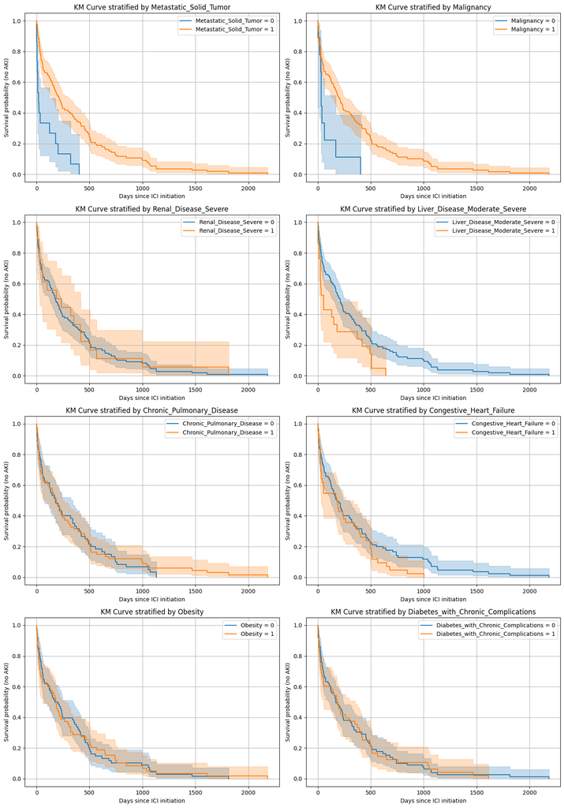

```python
import pandas as pd
import matplotlib.pyplot as plt
from lifelines import KaplanMeierFitter


comorbidity_vars = [
    'Metastatic_Solid_Tumor', 'Malignancy', 'Renal_Disease_Severe',
    'Liver_Disease_Moderate_Severe', 'Chronic_Pulmonary_Disease', 'Congestive_Heart_Failure',
    'Obesity', 'Diabetes_with_Chronic_Complications'
]

kmf = KaplanMeierFitter()

fig, axes = plt.subplots(4, 2, figsize=(14, 20))
axes = axes.flatten()

for i, var in enumerate(comorbidity_vars):
    ax = axes[i]
    for value in [0, 1]:
        mask = final_df[var] == value
        label = f"{var} = {value}"
        kmf.fit(final_df.loc[mask, 'time_to_event'], final_df.loc[mask, 'event_observed'], label=label)
        kmf.plot_survival_function(ax=ax)
    ax.set_title(f"KM Curve stratified by {var}")
    ax.set_xlabel("Days since ICI initiation")
    ax.set_ylabel("Survival probability (no AKI)")
    ax.grid(True)

plt.tight_layout()
plt.show()
```

```python
from lifelines.statistics import logrank_test

comorbidity_vars = [
   'Metastatic_Solid_Tumor', 'Malignancy', 'Renal_Disease_Severe',
    'Liver_Disease_Moderate_Severe', 'Chronic_Pulmonary_Disease', 'Congestive_Heart_Failure',
    'Obesity', 'Diabetes_with_Chronic_Complications'
]

results = []

for var in comorbidity_vars:
    group1 = final_df[final_df[var] == 0]
    group2 = final_df[final_df[var] == 1]

    result = logrank_test(
        group1['time_to_event'], group2['time_to_event'],
        event_observed_A=group1['event_observed'],
        event_observed_B=group2['event_observed'],
        alpha=0.95
    )

    results.append({
        'Variable': var,
        'Test Statistic': result.test_statistic,
        'p-value': result.p_value
    })

logrank_df = pd.DataFrame(results)
logrank_df['-log10(p)'] = -np.log10(logrank_df['p-value'])
logrank_df = logrank_df.sort_values('p-value')
print(logrank_df)
```

```
                              Variable  Test Statistic   p-value  -log10(p)
0               Metastatic_Solid_Tumor       18.043429  0.000022   4.665702
1                           Malignancy        8.057132  0.004532   2.343663
3        Liver_Disease_Moderate_Severe        5.281000  0.021559   1.666364
5             Congestive_Heart_Failure        2.239863  0.134493   0.871301
4            Chronic_Pulmonary_Disease        0.148113  0.700345   0.154688
2                 Renal_Disease_Severe        0.021037  0.884679   0.053214
7  Diabetes_with_Chronic_Complications        0.019429  0.889144   0.051028
6                              Obesity        0.000792  0.977546   0.009863
```

#### KM by SODH - Income

```python
income_cols = [
    'income_35k-50k', 'income_50k-75k', 'income_75k-100k',
    'income_150k-200k', 'income_more than 200k'
]

def get_income_group(row):
    for col in income_cols:
        if row[col]:
            return col.replace('income_', '')
    return 'Unknown'

final_df['income_group'] = final_df.apply(get_income_group, axis=1)
```

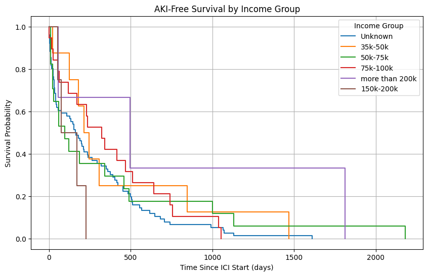

```python
from lifelines import KaplanMeierFitter
import matplotlib.pyplot as plt

kmf = KaplanMeierFitter()

plt.figure(figsize=(10, 6))

for group in final_df['income_group'].unique():
    subset = final_df[final_df['income_group'] == group]
    if not subset.empty:
        kmf.fit(durations=subset['time_to_event'], event_observed=subset['event_observed'], label=group)
        kmf.plot(ci_show=False)

plt.title("AKI-Free Survival by Income Group")
plt.xlabel("Time Since ICI Start (days)")
plt.ylabel("Survival Probability")
plt.legend(title="Income Group")
plt.grid()
plt.show()
```

```python
from lifelines.statistics import pairwise_logrank_test

results = pairwise_logrank_test(
    event_durations=final_df['time_to_event'],
    groups=final_df['income_group'],
    event_observed=final_df['event_observed']
)

print(results.summary)
```

```
                          test_statistic         p  -log2(p)
150k-200k 35k-50k               2.826802  0.092703  3.431244
          50k-75k               0.309059  0.578258  0.790214
          75k-100k              3.677389  0.055155  4.180360
          Unknown               0.753345  0.385419  1.375500
          more than 200k        1.852125  0.173536  2.526689
35k-50k   50k-75k               0.221770  0.637694  0.649063
          75k-100k              0.142302  0.706003  0.502253
          Unknown               0.903161  0.341936  1.548204
          more than 200k        0.905118  0.341413  1.550410
50k-75k   75k-100k              0.047031  0.828313  0.271752
          Unknown               0.503668  0.477893  1.065240
          more than 200k        0.707697  0.400210  1.321173
75k-100k  Unknown               0.999701  0.317383  1.655704
          more than 200k        1.338182  0.247355  2.015346
Unknown   more than 200k        3.044534  0.081009  3.625768
```